**162** <sup>|</sup>

wileyonlinelibrary.com/journal/jcpe

*J Clin Periodontol.* 2019;46(Suppl. 21):162–182.

© 2019 John Wiley & Sons A/S.

Published by John Wiley & Sons Ltd

**1** | **INTRODUCTION**

Reconstruction of oral and maxillofacial bone deficiencies is often a

clinical challenge. Ridge remodelling following tooth loss is the most

common cause for alveolar bone deficiencies in the horizontal and/

or vertical dimensions (Chiapasco & Casentini, 2018; Rocchietta,

Ferrantino, & Simion, 2018), and in the posterior edentulous max-

illa, this is further complicated by pneumatization of the maxillary

sinus(es) (Corbella, Weinstein, Francetti, Taschieri, & Del Fabbro,

2017; Danesh- Sani, Engebretson, & Janal, 2017). More challenging

segmental defects, which include the inferior mandibular border,

often result from trauma, tumour resection, or radiation- related os-

teonecrosis (Chanchareonsook, Junker, Jongpaiboonkit, & Jansen,

2014). Further, congenital anomalies are frequently associated

with alveolar defects such as orofacial clefts involving the maxilla

(Janssen, Weijs, Koole, Rosenberg, & Meijer, 2014).

Several regenerative surgical approaches have been proposed

to prevent and/or reconstruct alveolar defects, most commonly,

Received: 6 August 2018 | Revised: 17 October 2018 | Accepted: 26 October 2018

DOI: 10.1111/jcpe.13049

S U P P L E M E N T A R T I C L E

**Cell therapy for orofacial bone regeneration: A systematic**

**review and meta- analysis**

**Siddharth Shanbhag**<sup>**1**</sup>

| **Salwa Suliman**<sup>**1**</sup> | **Nikolaos Pandis**<sup>**2**</sup> | **Andreas Stavropoulos**<sup>**3**</sup>

|

**Mariano Sanz**<sup>**4**</sup>

| **Kamal Mustafa**<sup>**1**</sup>

1Department of Clinical Dentistry, Center

for Clinical Dental Research, University of

Bergen, Bergen, Norway

2Department of Orthodontics and

Dentofacial Orthopedics, University of Bern,

Bern, Switzerland

3Department of Periodontology, Faculty

of Odontology, Malmö University, Malmö,

Sweden

4Section of Periodontology, Faculty of

Odontology, University Complutense of

Madrid, Madrid, Spain

**Correspondence**

Kamal Mustafa, Department of Clinical

Dentistry – Tissue Engineering group,

Faculty of Medicine, University of Bergen,

Bergen, Norway.

Email: kamal.mustafa@uib.no

**Funding information**

This review was supported by funding

from Helse Vest, Norway (project number:

912048 K.M.), and the Bergen Stem Cell

Consortium (project number: 502027, K.M.)

**Abstract**

**Aim:** The objective of the present review was to answer the focused question: what

is the effect of cell therapy in terms of orofacial bone regeneration compared to

grafting with only biomaterial scaffolds and/or autogenous bone?

**Methods:** Electronic databases were searched for relevant controlled clinical and

pre- clinical (large- animal) studies. Separate meta- analyses of quantitative data re-

garding histological or radiographic new bone formation were performed.

**Results:** Forty- seven eligible clinical and 57 pre- clinical studies were included. Clinical

studies were categorized based on the use of “minimally manipulated” whole tissues

(e.g., bone marrow) or ex vivo expanded cells from “uncommitted” (bone marrow, adi-

pose tissue) or “committed” sources (periosteum, bone). Based on limited and hetero-

geneous clinical evidence, implantation of cells (mostly whole bone marrow), in

combination with biomaterial scaffolds results in bone regeneration which is (a) supe-

rior compared to implantation of scaffolds alone in sinus and horizontal ridge aug-

mentation, and (b) comparable to autogenous bone in alveolar cleft repair.

**Conclusions:** Although current evidence points to the benefits of cell therapy in cer-

tain clinical indications, it is unclear whether the use of ex vivo expanded cells, either

uncommitted or committed, is superior to whole tissue fractions in terms of bone

regeneration. The relatively larger effect sizes in favour of cell therapy observed in

pre- clinical studies are diminished in clinical trials. Future controlled studies should

include cost- effectiveness analyses to guide clinical decision- making.

**K E Y W O R D S**

bone grafting, bone tissue engineering, cell therapy, mesenchymal stem cells, meta-analysis,

systematic review

**|** **163**

SHANBHAG et Al.

alveolar ridge/socket preservation (SP) following dental extraction

(Avila- Ortiz et al., 2016), vertical and horizontal ridge augmentation

(RA) (Daugela, Cicciu, & Saulacic, 2016; Elnayef et al., 2017, 2018),

maxillary sinus- floor augmentation (SA) (Danesh- Sani et al., 2017),

and alveolar cleft (AC) repair in the palatal aspect of the maxilla (Wu

et al., 2017). All of these techniques mainly involve the use of autoge-

nous bone (AB) grafts and/or bone substitute materials, and often

in combination with barrier membranes, that is the guided bone re-

generation (GBR) principle (Elgali, Omar, Dahlin, & Thomsen, 2017);

in the case of more advanced (e.g., segmental) defects, vascularized

tissue flaps are used (Hayden, Mullin, & Patel, 2012). Although AB

transplantation is still considered the gold standard, larger defects

may require volumes of bone locally unavailable, leading to the need

for harvesting from a second surgical site, usually involving general

anaesthesia, hospitalization and significantly increased costs (Dahlin

& Johansson, 2011). Thus, the morbidity associated with invasive

AB harvesting and flap transfer, especially from a remote donor site,

along with its unpredictable resorption rate, are major limiting fac-

tors (Nkenke & Neukam, 2014; Shanbhag, Shanbhag, & Stavropoulos,

2014). Alternatives have included a range of allogeneic, xenogeneic

and alloplastic AB substitutes, but no consensus currently exists

on the effectiveness of one material over the other, in comparison

with AB, or for specific clinical indications (Al- Nawas & Schiegnitz,

2014; Milinkovic & Cordaro, 2014; Sanz- Sánchez, Ortiz- Vigón, Sanz-

Martín, Figuero, & Sanz, 2015).

Adult or postnatal stem cells represent promising candidates for

regenerative therapy, since they have the potential to replicate in

an undifferentiated state as well as to differentiate along commit-

ted lineages. Although adult stem cells are utilised in the clinic since

many decades as haematopoietic stem cell (HSC) therapy through

bone marrow transplantation (Mohty, Richardson, McCarthy, &

Attal, 2015), more recently, a multipotent population of mesen-

chymal stromal or “stem” cells (MSCs) was identified in the non-

haematopoietic fraction of bone marrow (Friedenstein, Chailakhjan,

& Lalykina, 1970). These MSCs have been defined by various char-

acteristics, such as plastic adherence, self- renewal or colony forming

unit (CFU)- potential, stromal phenotype and surface marker expres-

sion (CD73<sup>+</sup>CD90<sup>+</sup>CD105<sup>+</sup>CD34<sup>−</sup>CD45<sup>−</sup>HLA- DR<sup>−</sup>), and the ability to

differentiate into at least three stromal lineages, that is bone, fat and

cartilage (Dominici et al., 2006). In addition to their differentiation

capacity, MSCs also exert paracrine or trophic effects, via secretion

of soluble bioactive molecules, which “empower” host progenitor

cells and modulate immune cells (and thereby the immune response),

to promote regeneration (Wang, Chen, Cao, & Shi, 2014). In fact, re-

cent observations point to trophic activity as the primary mechanism

of MSC- mediated regeneration, rather than direct differentiation

(Caplan, 2017; Haumer et al., 2018).

In this context, tissue engineering aims to combine and de-

liver the cellular (progenitor cells), extracellular (scaffolds) and/

or molecular elements (growth factors) involved in physiological

regenerative processes, for therapeutic applications. Specifically,

regarding bone tissue engineering (BTE), this usually involves har-

vesting osteogenic cells from an autologous source (e.g., bone

marrow, adipose tissue), their “chair- side” manipulation or ex vivo

amplification, and combination with an appropriate biomaterial

scaffold for in vivo implantation (Evans et al., 2007; Oryan, Kamali,

Moshiri, & Baghaban Eslaminejad, 2017). Thus, the “triad” of *osteo-*

*genic* cells, *osteoinductive* signals (growth factors released by cells),

and *osteoconductive* scaffolds, aims to replicate the properties of

AB, and alleviate the need for invasive harvesting (Oppenheimer,

Mesa, & Buchman, 2012). The cells can be harvested by minimally,

and relatively less, invasive techniques (compared to AB har-

vesting) from various tissues, most commonly bone marrow and

adipose tissues, under local anaesthesia, and without the need

for hospitalization. Thus, BTE strategies are indeed emerging as

promising alternatives to AB and/or biomaterial- based grafting,

as demonstrated by several pre- clinical and some clinical studies

(for reviews, see Janssen et al., 2014; Padial- Molina et al., 2015;

Shanbhag et al., 2015; Shanbhag, Pandis, Mustafa, Nyengaard, &

Stavropoulos, 2016, 2018; Miguita, Mantesso, Pannuti, & Deboni,

2017). Among these BTE strategies, three main interventions

using cell therapies have been tested: (a) use of “minimally manip-

ulated” whole tissue fractions; (b) use of more- than- minimally ma-

nipulated or ex vivo expanded *uncommitted* stem/progenitor cells;

and (c) use of ex vivo expanded *committed* bone- derived cells.

*Minimally manipulated whole tissue fractions* have mainly in-

cluded bone marrow aspirates—either whole (BMA) or concen-

trated (BMAC), adipose stromal vascular fraction (A- SVF), and

tissue “micrografts.” The rationale for using whole tissue fractions

are (a) feasibility of a chair- side protocol, (b) minimum cell manip-

ulation, (c) cost- effectiveness, and (d) delivery of a heterogeneous

cell population. In addition to minimizing the time and costs associ-

ated with clinical- grade cell culture—which requires expensive Good

Manufacturing Practice (GMP)–grade facilities, this approach gen-

erates a population of cells that is not comprised solely of MSCs,

but also includes a number of other cell types with therapeutic

potential, including HSCs, endothelial cells (ECs), and immune cells

(monocytes, macrophages, etc.) (Fraser et al., 2014). This preserves

the physiological microenvironment or “niche,” with all cells in their

natural ratios, including those which produce paracrine signals to in-

duce host osteoprogenitors and MSCs (Jager et al., 2011).

Clinical relevance

*Scientific rationale for study:* Although cell therapy has

shown the potential to enhance bone regeneration, there

are several aspects regarding the source(s) of cells, their

manipulation, mode of application, as well as the cost-

benefit that need further elaboration.*Principal findings:*

Cell therapy may enhance alveolar bone regeneration in

specific clinical indications.*Practical implications:* Further

clinical trials are needed before cell therapy can become a

routine clinical procedure.

**164** **|**

SHANBHAG et Al.

Bone marrow is known to contain a heterogeneous population of

progenitor cells (including MSCs, HSCs, and endothelial progenitor

cells), and supporting growth factors and cytokines (Chahla et al.,

2016; Patterson et al., 2017). Concentration of the mononuclear cell

fraction (MNC) of bone marrow (which includes MSCs) via density

gradient centrifugation steps to remove red blood cells, granulo-

cytes, immature myeloid precursors, and platelets, represents an

attractive clinical strategy, since it is currently FDA- approved and

shown to be efficacious as a point- of- care method of autologous

cell delivery (Chahla et al., 2017; Jager et al., 2011). Moreover, since

self- renewing, plastic- adherent MSCs represent only a small fraction

(0.001%–0.01%) of MNC within the bone marrow, it may be hypoth-

esized that a concentrate (BMAC) could increase the likelihood of

attachment of these cells when loaded onto biomaterial scaffolds,

and thereby ensure successful delivery to the defect site (El- Jawhari,

Sanjurjo- Rodriguez, Jones, & Giannoudis, 2016).

An emerging and relatively less invasive alternative tissue source

for minimally manipulated cell fractions is A- SVF, which, like bone

marrow, contains a sub- population of adipose stem/stromal cells

(ASCs) in addition to hematopoietic and ECs. Since the frequency

of ASCs in A- SVF is reportedly much higher than that of BMSCs in

BMA(C), the direct use of A- SVF, without culture- expansion, has

been advocated (Fraser et al., 2014). However, although the use

of minimally manipulated whole tissue fractions may be time- and

cost- effective, the yield of progenitor cells obtained is relatively low.

MSCs represent <1% of the MNC in BMA, and approximately 1.4%

in A- SVF, based on CFU potential (Prins, Schulten, Ten Bruggenkate,

Klein- Nulend, & Helder, 2016). This has encouraged ex vivo expan-

sion strategies, which aim to exponentially increase the number of

cells of a specific phenotype, that is *committed* or *uncommitted*, avail-

able for implantation, and thereby improve clinical outcomes (Petite

et al., 2000).

The use of expanded *uncommitted* cells is based on the fact that

MSCs, originally identified in bone marrow (BMSCs), are the most

commonly reported cells in autologous regenerative therapies.

MSCs have also been isolated from less invasive sources such as ad-

ipose tissue (ASCs), dental tissues and a range of adnexal gestational

tissues, among others (Nancarrow- Lei, Mafi, Mafi, & Khan, 2017).

Although MSCs from different tissue sources share biological char-

acteristics, they have been reported to show functional differences

in their properties, such as surface phenotype and differentiation

potential (Al- Nbaheen et al., 2013). However, whether or not the tis-

sue of origin regulates the epigenetics of MSCs and affects their sub-

sequent in vivo differentiation potential remains to be determined in

a comparative clinical study.

The use of expanded *committed* cells is based on obtaining as

tissue source the alveolar bone itself—specifically, the periosteum

and cancellous bone/marrow. The periosteum has been described

as an osteoprogenitor cell- containing bone envelope with high re-

generative potential (Hutmacher & Sittinger, 2003), while marrow-

resident osteoblasts (OBs) are the fundamental cells of bone

tissue involved in its formation, function, repair, and maintenance

(Jayakumar & Di Silvio, 2010). Although multipotent MSC- like cells

have been identified in both periosteum (Olbrich, Rieger, Reinert, &

Alexander, 2012) and alveolar bone (Mason, Tarle, Osibin, Kinfu, &

Kaigler, 2014), for the purpose of this review, cells obtained from

these tissues were considered to be more osteogenically “commit-

ted” than those from other tissues (Akintoye et al., 2006; Pettersson,

Kingham, Wiberg, & Kelk, 2017).

It was therefore the primary objective of the present review to

systematically assess the literature to answer the focused question:

in clinical studies, what is the effect of cell therapy in terms of oro-

facial bone regeneration compared to grafting with only biomaterial

scaffolds and/or AB? Secondary objectives were (a) to assess the

preclinical to clinical translation of cell therapy by comparing preclin-

ical and clinical data, and (b) to determine which is the most suitable

cell therapy approach for regenerating bone deficiencies.

**2** | **MATERIALS AND METHODS**

Following Cochrane (Higgins & Green, 2011) and Preferred Reporting

Items for Systematic Reviews guidelines (Moher, Liberati, Tetzlaff, &

Altman, 2009), an electronic literature search based on pre- defined

inclusion criteria was performed in 3 repositories (PubMed, Embase

and Cochrane library) up to May 2018 (Figure 1). Sampling of the

clinical evidence was focused on controlled trials—either rand-

omized (RCT) or non- randomized (CT). Uncontrolled studies (UT)

and cases reports (with ≥3 patients) of cell- based BTE were also

identified to capture possible relevant information regarding cell

sources, delivery strategies, and adverse events, although data re-

garding bone regeneration from these studies were not considered

for the meta- analyses. Sampling of pre- clinical data was limited to

large- animal models and regards mainly an update of our previously

published reviews (Shanbhag et al., 2016, 2018). These data were

only included to compare with the clinical data, which is the focus of

the present review. Quantitative data regarding histomorphometric

or radiographic bone regeneration was included in meta- analyses.

Separate analyses were performed for clinical (grouped by indica-

tion/defect- type and method of outcome evaluation) and pre- clinical

studies (grouped by species and defect- type). Details of the review

methodology are reported in the Appendix.

**3** | **RESULTS**

**3.1** | **Summary of included studies**

After screening, 47 controlled clinical studies were included, of

which 22 were RCTs, mostly with a low to unclear risk of bias

(Supporting Information Figure S8). Additionally, 30 UT and case

series were identified (Supporting Information Tables S1–S3).

A majority of the evidence was derived from studies of SA and

ing fracture, cystectomy or tumour resection, were identified

(Table 1). Most studies included a “split- mouth” design, utilized a

**|** **165**

SHANBHAG et Al.

GBR approach for augmentation, that is a membrane to cover the

cell- scaffold construct, and reported the placement of implants

in regenerated sites. Outcomes were assessed via in situ clinical

examination and/or radiography [computed tomography (CT) or

cone- beam CT (CBCT)], or via histological and/or micro- CT (μ- CT)

assessments of biopsy specimens. The primary outcome measure

was quantitative assessments of new bone formation (NBF) via

histomorphometry or μ- CT of biopsies, or in situ CT- based assess-

ments of “bone fill” (BF) within the treated defects.

Scaffolds used (xenogeneic and alloplastic) to deliver cells to the

regeneration sites were: (a) *ceramic* scaffolds, such as deproteinized

bovine bone mineral (DBBM), hydroxyl- apatite (HA), beta- tricalcium

phosphate (β- TCP), biphasic HA/β- TCP (BCP) and freeze- dried bone

allograft (FDBA); (b) *polymeric* scaffolds, such as collagen (COL) or

gelatin sponges, platelet- rich/poor plasma (PRP/PPP) or fibrin (PRF),

and polylactic–polyglycolic acid copolymer (PLGA); or (c) *composite*

scaffolds, including various combinations of the above (Lee, Cuddihy,

& Kotov, 2008).

Cell therapy approaches were categorized according to US

Food and Drug Administration (FDA) guidelines on the use of

Human Cells, Tissues, and cellular and tissue- based Products

(HCT/P; Code of Federal Regulation Title 21- CFR- 1271) and

the European Medicines Agency (EMA) guidelines on the use

Advanced Therapy Medicinal Products (ATMP; European

Regulation 1394/2007), as: (1) “minimally manipulated” whole

tissue fractions, usually involving a point- of- care or chair- side

procedure, or (2) “more- than- minimally manipulated”, that is ex

vivo culture- expanded cells, further categorized (for the pur-

pose of this review) as (a) uncommitted stem/progenitor cells,

and (b) committed bone- derived cells (Supporting Information

Figure S1). Summaries of the included clinical studies in each cat-

egory are presented in Tables 2–4.

**Indication**

**Uncontrolled**

**Controlled**

SA

7

25

RA

4

6

SA and/or RA (in the same patients or in different

patients in the same study)

10

–

Ridge/SP

–

5

AC

3

7

CD

3

–

Other (fracture, cyst, tumour resection)

3

4

Total

30

47

SA: sinus augmentation; RA: ridge augmentation; SP: socket preservation; AC: alveolar cleft; CD:

cranial defect.

TA B LE 1 Distribution of included

clinical studies according to indications

FI G U R E 1 Flow chart for study

inclusion (n = number of articles)

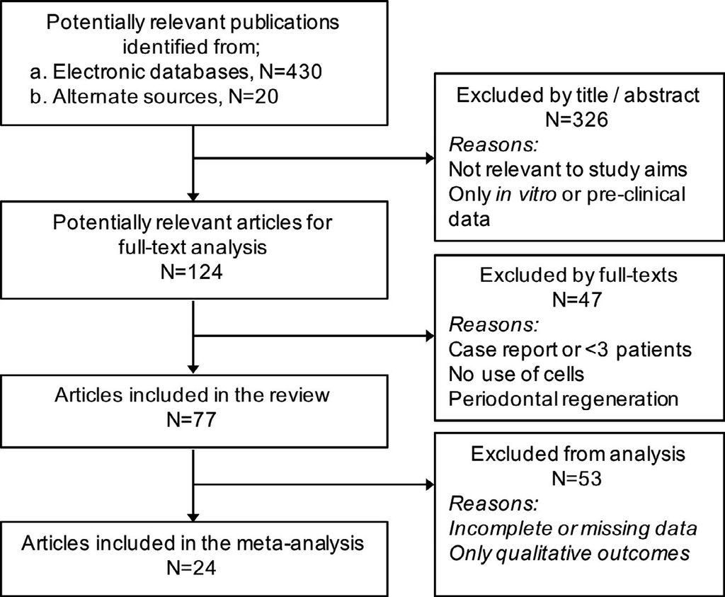

**166** **|**

SHANBHAG et Al.

TA B LE 2 Summary of controlled studies using whole tissue fractions

**Study (design)**

**Site**

**Patients (sex, age)**

**Cell therapy group**

**Control group**

**Follow- up**

**Method**

**Outcome**

**Cell source (culture)**

**Scaffold**

**BMA or BMAC (n = 19)**

Wojtowicz et al., 2003;

Wojtowicz, Chaberek,

Urbanowska, &

Ostrowski, 2007 (CC)

Cyst—max or man

(15–21 mm)

17 (17M, 27–44 y)

Iliac BMA (*whole*, 1.4 ± 0.1 x108

MNC + 0.9 ± 0.1 × 106 CD34 +

cells/transplant) *or* BMA (*Ficoll*,

0.6 ± 0.1 × 108 MNC + 1.9 ± 0.2 ×

106 CD34 + cells/transplant)

DBBM (Bio- Oss®) +

PRF/Col mem

PRP + DBBM + PRF/

Col mem

3 m

Radio

PRP > BMA

Gimbel et al., 2007 (CC)

AC—uni

69 (6–12 y)

Iliac BMA (40 ml, passed through

heparinized column)

Col sponge

(Healos®)

Iliac AB (conventional

*or* minimal invasive)

6w, 6 m, 2y

Clinical

Patient-

reported

+ (pain, cost

T<C)

Sauerbier et al., 2010

(CT); *Duttenhoefer* et al.*,*

*2014*

SA (<3 mm) —uni/bi

11 (47–69 y)

Iliac BMAC (Harvest®, 3 ml)

DBBM (Bio- Oss®)

*BMA (Ficoll)* + DBBM

3 m

2.5 y

Histo

IS

NS

NS

Sauerbier et al., 2011

(RCT)

SA (<3 mm) —uni/bi

26 (38–68 y)

Iliac BMAC (Harvest®, 3 ml)

DBBM (Bio-Oss®)

DBBM + Man AB

(70:30)

3–4 m

Histo

NS

Rickert et al., 2011 (RCT);

*Rickert* et al.*,* *2014*

SA (<4 mm) —bi

12 (48–69 y)

Iliac BMAC (Harvest®, 3 ml)

DBBM (Bio-Oss®)

DBBM + Man AB

(70:30)

13–16 w

12 m

Histo

IS

*S*

C>T

Wildburger et al., 2014

(RCT), *Kuhl* et al.*,* *2014*

SA (<3 mm) —bi

7 (47–72 y)

Iliac BMAC (Harvest®, 3 ml)

DBBM (Bio-Oss®)

DBBM only

3, 6 m

0.5, 6 m

Histo

CT (V)

NS

NS

Payer et al., 2014 (RCT),

*Kuhl* et al.*,* *2014*

SA (<3 mm) —bi

6 (3M, 43–70 y)

Tibial BMA (8 ml)

DBBM (Bio- Oss®)

DBBM only

3, 6 m

0.5, 6 m

Histo

CT (V)

NS

NS

Sununliganon (2013)

(RCT)

SA (<5 mm) —uni/bi

± impl

4 (bi, 2F, 30–71 y); 9

(uni, 6M, 23–72 y)

Iliac BMAC (MarrowStim®, 3 ml)

BBM (Endobon®)

BBM only *or*

Iliac AB

7 m

3, 6 m, 1,

2y

Histo (qual)

μCT (BV/

TV%)

NS

NS

Bertolai et al., 2015 (RCT)

SA (<5 mm) —bi

20 (10M, 55.2 y)

Iliac BMAC (Regen®, 14–15 ml)

FDBA + PRP

FDBA only

3 m

Histo (qual)

T>C

Pasquali et al., 2015

(RCT)

SA (<4 mm) —bi

8 (~55y)

Iliac BMAC (Harvest®, 4 ml)

DBBM (Bio- Oss®)

DBBM only

6 m

Histo

*S*

De Oliveira et al., 2016

(RCT)

SA (<4 mm) —uni/bi

15 (12F, ~55y)

Iliac BMA—single *or* double

centrifugation

DBBM (Bio- Oss®)

DBBM only

6 m

Histo

NS

Pelegrine, da Costa,

Correa, & Marques, 2010

(RCT)

SP

13 (7M, 28–70 y)

Iliac BMA (4–5 ml)

None

Empty (clot)

6 m

Histo

NS

Da Costa, Pelegrine,

Fagundes, Simoes Mde,

& Taha, 2011 (RCT)

RA—ant max (hor;

<5 mm)

10 (8F, 40–55 y)

Iliac BMAC (Harvest® 4 ml)

Allograft block

Allograft only

6 m

Histo

*S*

Pelegrine et al., 2016

(RCT)

RA—ant max (hor;

<3 mm)

8 (~52y)

Iliac BMAC (Harvest® 4 ml)

EBM (Bio- Gen®)

EBM only

4 m

4, 8 m

Histo

CBCT (BG)

NS

(Continues)

**|** **167**

SHANBHAG et Al.

**Study (design)**

**Site**

**Patients (sex, age)**

**Cell therapy group**

**Control group**

**Follow- up**

**Method**

**Outcome**

**Cell source (culture)**

**Scaffold**

Lavareda Correa et al.,

2017 (RCT)

RA—ant max (hor;

2–4 mm)

10 (8F, 36–52 y)

Iliac BMAC (Harvest® 4 ml)

Allograft block +

granules

Allograft only

6 m

Histo

CBCT (BV,

BD)

NS

NS

Marx & Harrell, 2014

(RCT)

RA—man SD (6–8

cm)

40 (22M, 19–78 y)

Iliac BMA (10 ml; 15.5 × 106/ml

TNC + 54 ± 38/ml CD34 + ) *or*

BMAC (Harvest® 10 ml; 98 × 106/

ml TNC + 1000 ± 750/mL CD34 +

cells)

Allograft +

rhBMP- 2/Col

sponge

*BMA* + scaffold

6 m

Histo

CT

*S*

*S*

Talaat, Ghoneim, Salah, &

Adly, 2018 (RCT)

Cyst—mand

20 (13M, 18–50 y)

Iliac BMAC (Harvest® 6–9 ml)

PRP + Col sponge

Empty defects

3, 6, 12 m

Panoramic

*S*

Du et al., 2017 (CT)

AC—uni

20 (12F, 8–28 y)

Iliac BMAC (TBD® 1 ml)

β- TCP (Bio- lu®)

Iliac AB

6, 12 m

CT (BV/TV%)

NS

Al- Ahmady et al., 2018

(RCT)

AC—uni

20 (12F, 8–18 y)

Iliac BMA (*Ficoll* 2 ml)

Col sponge- nHA +

PRF

Iliac AB

6, 12 m

CBCT (grade)

T>C

**Adipose SVF (n = 1)**

Prins et al., 2016 (CT);

*Farre-Guasch* et al.*,* *2018*

SA (4–8 mm) —uni/

bi

10 (6F, 46–69 y)

Abdominal SVF (Celution®, 5 ml

cell susp., mixed pop., 83% CD90

+ , 67% CD34 + ), 2 × 107 cells/2

g scaffold/SA (1.4 × 105 CFU- F/g)

β- TCP (Ceros®) or

BCP (Bone

Ceramic®)

β- TCP *or* BCP only

6 m

6 m

2.5y

Histo

μCT

IHC (CD34,

SMA)

IS

*S*NS

NS

100%

**Micrografts (n = 4)**

d’Aquino et al., 2009

(CT); *Giuliani* et al., *2013*

SP—bi

7

Dental pulp- derived (Rigenera®)

Col sponge

(Gingistat®)

Col sponge only

3 m

36 m

Histo (qual)

Histo

T>C

*S*

Monti et al., (2016) (CT)

SP—bi

6 (4F, 22–60 y)

Dental pulp-derived (Rigenera®)

Col sponge only

45–70 days

Histo (qual)

T>C

D’Aquino et al. (2016)

(CT)

SP (multi- rooted)

—bi

35 (21F, 25–64 y)

Max periosteum- derived

(Rigenera®)

Col sponge

(Gingistat®)

Col sponge only

45–90 days

Clinical

Histo (qual)

*S*

T>C

Rodriguez et al. (2017)

(CT)

SA—uni

24 (12F, 45–64 y)

Max periosteum-derived

(Rigenera®)

PLGA/HA

PLGA/HA *or* DBBM

(Bio- Oss®)

4 m

Histo

*S*

CT: controlled trial; RCT: randomized CT; CC: case–control; SA: sinus augmentation; RA: ridge augmentation/GBR; SP: socket preservation; AC: alveolar cleft; SD: segmental or continuity defects; CD:

cranial defect; ORN: osteoradionecrosis; uni: unilateral; bi: bilateral; imp: simultaneous implant placement; man: mandible; max: maxilla; hor: horizontal; M: male; F: female; y: years; m: months; w: weeks;

Histo: histomorphometry; Histo (qual): qualitative histology; IHC: immunohistochemistry; Radio: radiographic; CT: computed tomography; V: volume; μCT; micro- CT; BV/TV: bone volume/total volume; BG:

bone gain; T: test group; C: control group; Comp: complications; IS: implant survival; +: favourable bone regeneration outcomes; BMA: bone marrow aspirate; BMAC: bone marrow aspirate concentrate; AB:

autogenous bone; HA: hydroxyl- apatite; β- TCP: beta- tricalcium phosphate; BCP: biphasic calcium phosphate; BAG: bioactive glass; GAG: glycosaminoglycans; Col: collagen; DBBM: demineralized bovine

bone mineral; ABB: anorganic bovine bone; Pep: PepGen; PRP: platelet- rich plasma; PRF: platelet- rich fibrin; rhBMP- 2: recombinant human bone morphogenetic protein- 2; FD: freeze- dried; PLA: poly-

lactide; PLGA: polylactic- co- glycolic acid; *study/year in italics*: follow- up study reporting on the same patient sample; *S*: statistically significant differences between T and C groups; NS: no statistically signifi-

cant differences between T and C groups.

TA B LE 2 (Continued)

**168** **|**

SHANBHAG et Al.

Fifty- seven eligible pre- clinical in vivo studies in large- animal

models [dogs, minipigs and small- ruminants (sheep and goats)] were

also identified (Supporting Information Tables S4–S6). These studies

represented SA, RA [in the form of critical size defects (CSD)], and

AC models. The following section is focused on results of the meta-

analyses. Details of the included clinical studies, along with relevant

supporting literature, are presented in the discussion.

**3.2** | **Meta- analyses: Effect sizes of cell therapy**

The clinical evidence is mostly based on randomized (SA, RA) and

morphometry (NBF), μ- CT [regenerated bone volume/total volume

(BV/TV)] or CT (BF) were included in separate meta- analyses. Pooled

estimates of treatment effect [effect sizes (ES)] were calculated for

the outcomes NBF, BV/TV and BF in SA/RA, SA and AC repair, re-

spectively. For SA studies, sub- group analyses were performed ac-

cording to the time of biopsy, that is at 3–4 months or 6 months after

augmentation. Additionally, regression analyses were performed to

evaluate the effect of time (</>6 months) and types of cells used

(whole tissue, uncommitted or committed) on bone regeneration.

Overall, the clinical meta- analyses revealed:

a). in SA, significantly greater bone regeneration was observed

after cell therapy in 1 meta-analysis of histomorphometric re-

sults (ES: 4.12% NBF, 6 studies, vs. scaffolds, 6 months) and in

1 meta-analysis of μ-CT results (ES: 4.76% BV/TV, 3 studies,

vs. scaffolds, 4–7 months), while in 1 meta-analysis of histo-

morphometric results no benefit was observed (12 studies, vs.

scaffolds, 3–4 months). Based on a meta-regression analysis of

histomorphometric data from 15 studies, there were no differ-

ences between the various cell therapy strategies, that is whole

tissues vs. expanded uncommitted cells vs. expanded committed

cells, in terms of the amount of bone regeneration (Supporting

Information Table S7).

b). in horizontal RA, significantly greater bone regeneration was ob-

served after cell therapy in 1 meta-analysis of histomorphometric

results (ES: 13.42% NBF, 3 studies, vs. scaffolds; 1 study, vs. scaf-

fold + AB, 4–6 months).

c). in AC defects, 1 meta-analysis failed to show a benefit of cell ther-

apy over AB, as evaluated with CT (3 studies, 6 months).

Overall, the clinical meta- analyses revealed moderate to high het-

erogeneity (I<sup>2</sup> 70%–99%), and wide predictive intervals, often crossing

the line of no effect (Table 5, Supporting Information Figures S2–S4).

A meta- analysis of 57 eligible preclinical studies was also per-

formed to compare the preclinical and clinical evidence for cell ther-

apy and thereby assess its translation. To allow comparison with

clinical data, similar pooled estimates (ES) were calculated for histo-

morphometric NBF. Sub- group analyses according to species and

observation times were performed; analysis according to cell types

(whole tissue, uncommitted or committed) could not be performed

due to insufficient numbers of studies/comparisons in each sub-

group. Overall, the pre- clinical meta- analyses revealed:

a). in SA models, significantly greater bone regeneration was ob-

served after cell therapy in dogs (ES: 10.21% NBF, 5 studies, vs.

scaffolds, <6 months) and small-ruminants (ES: 11.11% NBF, 3

studies, vs. AB, 2–4 months).

b). in CSD models, significantly greater bone regeneration was ob-

ies, vs. scaffolds, 1–2/2–4 months and ES: 48.73%, 3 studies, vs.

scaffolds, 12 months), pigs (ES: 14.84% NBF, 4 studies, vs. scaf-

folds, 2–3 months) and small-ruminants (25.78% NBF, 3 studies,

vs. scaffolds, 3–5 months).

c). in AC defect models, no significant benefit of cell therapy over AB

was observed in dogs (3 studies, 2–5 months).

Similar to clinical studies, the pre- clinical meta- analyses also re-

vealed moderate to high heterogeneity (I<sup>2</sup> 60%–99%) with wide pre-

dictive intervals (Table 5, Supporting Information Figures S5–S7).

However, for all comparisons, larger ES were observed in the pre-

clinical vs. clinical meta- analyses.

**4** | **DISCUSSION**

The primary objective of the present review was to assess the cur-

rent clinical evidence on the effectiveness of cell therapy for orofa-

cial bone regeneration, compared to grafting with only biomaterial

folds seems to be (a) superior to implantation of scaffolds alone in SA

(based on histological and μ- CT outcomes) and horizontal RA (based

on histological outcomes), and (b) comparable to AB grafts in AC re-

pair (based on CT outcomes). Although the meta- analyses revealed

statistically significant outcomes for these comparisons, heteroge-

neity in the studies was high as evidenced by the wide prediction in-

tervals (Table 5). While the current available evidence is insufficient

to determine the best strategy in terms of cell–types and –sources

(whole tissue, uncommitted or committed), a discussion around this

topic seems to be clinically important and is presented herein.

**4.1** | **Use of minimally manipulated whole**

**tissue fractions**

A majority of included studies reported the use of minimally ma-

nipulated whole tissue fractions, particularly bone marrow—as

either whole (BMA) or concentrated (BMAC) aspirates (Table 2,

Supploring Information Table S1). In several studies, significantly

greater NBF was observed when using autologous BMAC- loaded

vs. cell- free scaffolds (most commonly DBBM) in SA and RA. While

a majority of studies reported harvesting from the iliac crest, one

study each reported harvesting from the femur (Ibanez, Agustina,

Ibanez, & Ibanez, 2012) and tibia (Payer et al., 2014). Regarding the

**|** **169**

SHANBHAG et Al.

TA B LE 3 Summary of controlled studies using “uncommitted” culture- expanded cells

**Study (design)**

**Site**

**Patients (sex,**

**age)**

**Cell therapy group**

**Control group**

**Follow- up**

**Method**

**Outcome**

**Cell source (culture)**

**Cell number**

**Scaffold**

**BMSCs (n = 5)**

Hernandez Alfero

et al. (2005) (RCT)

SA (3–13 mm)

—bilat

5 (5F, 37–75 y)

Replicell® or

Ixymyelocel- t® Iliac

“TRCs” (IMDM + 10%

FBS + 10% HS,

12–14 days)

7–20 × 107 cells/SA

DBBM

(Bio- Oss®) + PPF

DBBM+ PPF

4 m

Histo

CT

NS

Kaigler et al. (2015)

(RCT)

SA (2–6.2 mm)

—unilat

26 (10F,

26–66 y)

Replicell® or

Ixymyelocel-t® Iliac

“TRCs”

1.6–15 × 107 cells/SA

β- TCP (Cerasorb®)

β- TCP only

4 m

Histo

μCT

*Unclear*

NS overall

Kaigler et al. (2013)

(RCT)

SP—unilat

24 (13F,

31–63 y)

Replicell® or

Ixymyelocel-t® Iliac

“TRCs”

1.5 × 107 cells/SP

Gelatin sponge

(Gelfoam®)

Gelatin sponge

only

6, 12 w

Histo

μCT

NS

*S 6w*, NS 12w

Bajestan et al. (2017)

(RCT)

RA (hor; 2° to

AC or trauma)

17 (12M,

18–54 y)

Replicell® or

Ixymyelocel-t® Iliac

“TRCs”

1.5–4.4 × 107 cells/cc

(2–5 cc/pt)

β- TCP (Cerasorb®)

Man AB

4 m

Re- entry

NS

Comp

Khalifa and Gomaa

(2017) (CT)

AC

16 (7–12 y)

Iliac BMSCs (DMEM + 20%

AS, pass. 3)

5 × 105 cells/scaffold

HA- Si (Nanobone®)

Man AB

3, 6 m

CT

*S*

**ASCs (n = 5)**

Alekseeva, Kulakov

et al. (2012) (CT)

SA (<5 mm)

—uni/bilat

25 (29–60 y)

Abdominal ASCs

(DMEM/F12 + 10% AS,

osteo+ 7d)

5–7 × 106 cells/cm3

scaffold

HA- Col/GAG + PRP

DBBM

(Bio- Oss®) + PRP

4–6 m

Histo

CBCT

T>C

Khojasteh and

Sadeghi (2016) (CC)

RA—max/man

(hor)

8 (5M, 25–60 y)

Buccal fat pad ASCs

(DMEM + 10% AS, pass.

3–4)

106 cells/scaffold

Iliac AB + FDBA

granules

Iliac AB + FDBA

only

5 m

Histo

CBCT

T>C

NS

Khojasteh et al.

(2017) (CT)

AC—uni

10 (3F,

8–14 y + 4

adults)

Buccal fat pad ASCs

(DMEM + 10% AS, pass.

3–4)

106 cells/scaffold

Man AB + BBM

(Cerabone®) *or* Iliac

AB + BBM, + Col

mem

Iliac AB + Col mem

6 m

CBCT

Histo (n=2)

NS

Soliman, Ismail,

Shouman,

Bahaaeldin, and

El- Hadidy (2018) (CC)

AC—uni/bi

24 (15M,

7–27 y)

Abdominal ASCs

(DMEM + 10%–13% FBS)

3 × 106 cells/ml

Allograft *or* iliac AB

Iliac AB only

6 m

Radio

NS

Castillo- Cardiel et al.

(2017) (RCT)

Man condyle

fractures

20 (~29–31 y)

Abdominal ASCs

(DMEM + 10% FBS,

24 h)

NR

Open reduction

Open reduction

4, 12 w

CT (BD)

*S*

CT: controlled trial; RCT: randomized CT; CC: case–control; SA: sinus augmentation; RA: ridge augmentation/GBR; SP: socket preservation; AC: alveolar cleft; SD: segmental or continuity defects; CD: cranial defect;

ORN: osteoradionecrosis; uni: unilateral; bi: bilateral; imp: simultaneous implant placement; man: mandible; max: maxilla; hor: horizontal; M: male; F: female; y: years; m: months; w: weeks; Histo: histomorphometry;

Histo (qual): qualitative histology; IHC: immunohistochemistry; Radio: radiographic; CT: computed tomography; μCT; micro- CT; V: volume; BV/TV: bone volume/total volume; BG: bone gain; T: test group; C: control

group; Comp: complications; IS: implant survival; +: favourable bone regeneration outcomes; BMSC: bone marrow MSC; ASC: adipose tissue- derived MSC; TRCs: tissue repair cells; FBS: foetal bovine serum; HS:

horse serum; AS: autologous serum; osteo+: osteogenic induction; pass.: passage; AB: autogenous bone; HA: hydroxyl- apatite; Si: silica; β- TCP: beta- tricalcium phosphate; BCP: biphasic calcium phosphate; BAG: bio-

active glass; GAG: glycosaminoglycans; Col: collagen; DBBM: demineralized bovine bone mineral; ABB: anorganic bovine bone; Pep: PepGen; PRP: platelet- rich plasma; PRF: platelet- rich fibrin; *S*: statistically signifi-

cant differences between T and C groups; NS: no statistically significant differences between T and C groups.

**170** **|**

SHANBHAG et Al.

TA B LE 4 Summary of controlled studies using “committed” culture- expanded cells

**Study (design)**

**Site**

**Patients (sex, age)**

**Cell therapy group**

**Control group**

**Follow- up**

**Method**

**Outcome**

**Cell source (culture)**

**Cell number**

**Scaffold**

**POCs (n = 6)**

Springer et al. (2006) (CC)

SA—uni/bilat

8 (4F, 43–65 y)

Man POCs (aMEM + 20% AS,

osteo+, 21d)

6 × 106 cells/scaffold

+ 1 w culture

Col fleece

(Lyostypt®)

DBBM

(Bio- Oss®)

6–8 m

Histo (qual)

Radio

*S*

Zizelmann et al. (2007) (CT)

SA (<5 mm) —uni/

bilat ± impl

20

Man POCs (Bioseed-

Oralbone®, DMEM/F12 +

10% AS, pass. 3–4, osteo+,

6w, +fibrinogen)

1.5 × 106 cells/disc +

6–9 days culture

PLGA (Ethisorb®)

discs

Iliac AB

3 m

CT (V- loss%)

T 90%, C 29%

Voss et al. (2010) (CC)

SA (class 4,5) —uni/

bilat ± impl

35 (21F, 35–69 y)

(41C pts 38–73 y)

Man POCs

(Bioseed-Oralbone®)

1.5 × 106 cells/disc +

6–9 days culture

PLGA (Ethisorb®)

discs

Iliac AB

15 w

Histo (qual)

Comp

T > C

Mangano et al. (2009) (CT)

SA (2–10 mm)

—bilat

5 (3F, 45–64 y)

Man POCs

(Bioseed-Oralbone®)

1.5 × 106 cells/disc +

6–9 days culture

PLGA (Ethisorb®)

discs

CaP (Coral)

6 m

Histo

CT (BD)

C > T

C > T

Nagata et al. (2012) (CC)

SA (<2 mm) —uni/bi

(n = 15) or RA (hor

+ ver; n = 14)

25a (+15C pts)

(13F, 18–76 y)

Man POC sheet (M199 +

10% FBS + AA, 6w)

NR

Man AB + PRP

Man AB + PRP

4 m

3, 12 m

IHC

CT (V)

*S*

NS

Ogawa et al. (2016) (CC)

SA (<2 mm) —uni/

bilat

23a (+15C pts)

(10M, 40–70 y)

Man POC sheet

NR

Man AB + PRP

Man AB + PRP

4, 12 m

CT (V%)

NS

**OBs (n = 6)**

Pradel et al. (2006) (CC)

Man cysts

8 (7M, 8–16 y)

Max/man OBs (Exp, DMEM

+ 10% AS, osteo+, pass. 2,

8–12w)

5 × 105 cells/scaffold

DBBM (Osteovit®)

Iliac AB

3, 6, 12 m

Radio (BD)

NS

Pradel and Lauer (2012)

(CC)

AC—uni/bi

20 (15M, 16–72 y)

Max/man OBs

5 × 105 cells/scaffold

DBBM (Osteovit®)

Iliac AB

6 m

CBCT (%fill)

T 40.9%, C

36.6%

Pradel, Mai, Manolo

Hagedorn, Lauer, and

Allegrini (2008) (CC)

SA (mod- sev) —uni/

bi

6 (6F, 38–52 y)

Max/man OBs

5 × 105 cells/scaffold

DBBM (Osteovit®)

OBs + S-BBM

(Tutobon®)

5 m

Histo (qual)

S- BBM>BBM

Gonshor et al. (2011)

(RCT)

SA (<6 mm) —uni/

bilat

18 (12F, 42–79 y)

Cellular allograft (Osteocel®)

>5 × 104 cells/cm3

Allograft

Allograft only

3–4 m

Histo

*S*

Springer et al. (2006) (CC)

SA—uni/bilat

5 (4F, 43–65 y)

Max tuberosity OBs (Exp,

DMEM + 20% AS)

3.3 × 106 cells/cm2

scaffold (+40 days

cult)

DBBM (Bio- Oss®)

DBBM only

6–8 m

Histo (qual)

Radio

*S*

Hermund, Stavropoulos,

(2012), *Hermund et al.,*

*(2013)* (RCT)

SA (<3 mm)—uni

20 (11F, ~58–60 y)

Max tuberosity OBs (Exp,

DMEM/F12 + 20% FBS +

AA, 10% AS 1w, 1 m)

2 × 106 cells/ml

DBBM (Bio- Oss®)

+ Max AB (1:1)

DBBM + Max AB

(1:1)

4 m

*IS*Histo

NS

NS

CT: controlled trial; RCT: randomized CT; CC: case–control; SA: sinus augmentation; RA: ridge augmentation/GBR; SP: socket preservation; AC: alveolar cleft; SD: segmental or continuity defects; CD:

cranial defect; ORN: osteoradionecrosis; uni: unilateral; bi: bilateral; imp: simultaneous implant placement; man: mandible; max: maxilla; hor: horizontal; ver: vertical; mod- sev: moderate- severe; M: male; F:

female; y: years; m: months; w: weeks; Histo: histomorphometry; Histo (qual): qualitative histology; IHC: immunohistochemistry; Radio: radiographic; CT: computed tomography; V: volume; BD: bone den-

sity; T: test group; C: control group; Comp: complications; IS: implant survival; +: favourable bone regeneration outcomes; POCs: periosteal cells; OBs: osteoblasts; Exp: explant culture; FBS: foetal bovine

serum; HS: horse serum; AS: autologous serum; osteo+: osteogenic induction; pass.: passage; AB: autogenous bone; HA: hydroxyl- apatite; Si: silica; β- TCP: beta- tricalcium phosphate; BCP: biphasic calcium

phosphate; BAG: bioactive glass; GAG: glycosaminoglycans; Col: collagen; DBBM: demineralized bovine bone mineral; ABB: anorganic bovine bone; Pep: PepGen; PRP: platelet- rich plasma; PRF: platelet-

rich fibrin; *S*: statistically significant differences between T and C groups; NS: no statistically significant differences between T and C groups; a: overlapping patient samples.

**|** **171**

SHANBHAG et Al.

morbidity associated with BMA harvesting, lower donor site mor-

bidity and donor site pain- intensity and - frequency were reported

in patients treated with BMA/scaffolds vs. iliac AB grafting for AC

repair (Gimbel et al., 2007). In one RCT of mandibular segmen-

tal defect- repair (Marx & Harrell, 2014), significantly greater NBF

was observed when using BMAC—containing a higher fraction of

CD34<sup>+</sup> cells (1012 ± 752 cells/ml) compared to un- concentrated

BMA (54 ± 38 cells/ml), although both groups had similar concentra-

tions of CD90<sup>+</sup>CD105<sup>+</sup> MSCs (15 × 10<sup>6</sup> cells/ml) and were delivered

in combination with rhBMP- 2- loaded COL and allograft scaffolds.

Interestingly, the NBF was higher when BMAC (67% ± 13%), but not

BMA (36% ± 10%), was added to the constructs compared to only

rhBMP- 2 (+PRP; 59% ± 12%) or AB (54% ± 10%), as reported by the

group in a previous study (Marx, Armentano, Olavarria, & Samaniego,

2013). The authors highlighted an important complimentary role of

CD34<sup>+</sup> HSCs in MSC- mediated bone regeneration, and the benefits

of implanting heterogeneous cell populations at regeneration sites

(Marx & Harrell, 2014).

One controlled trial (Prins et al., 2016) reported the application

of autologous A- SVF for SA via enzymatic digestion of abdominal

adipose tissues using a chair- side isolation system (Celution<sup>®</sup>, Cytori

Therapeutics, San Diego, CA, USA). Significantly greater NBF was

TCP or BCP scaffolds after 6 months—most markedly in the “cranial”

portion of the augmentation sites distant from the native residual

ridge (Prins et al., 2016). Interestingly, subsequent immunohisto-

chemical analyses of biopsy specimens also revealed a higher quan-

tity and quality/maturity of blood vessels in the areas of active bone

formation (Farre- Guasch et al., 2018). Similar results were observed

in a phase I clinical study of orthopaedic fracture treatment with A-

SVF (Saxer et al., 2016). Indeed, previous studies have demonstrated

the angiogenic and vasculogenic potential of A- SVF, attributed to the

TA B LE 5 Comparison of cell therapy effect sizes in preclinical and clinical meta- analyses

**Preclinical**

**Clinical**

**Category**

*n*

**ES**

**95% CI**

**PI**

**Category**

*n*

**ES**

**95% CI**

**PI**

**Sinus augmentation**

Dogs

vs.

Scaffolds

(<6 m)

5

10.21

4.00, 16.42

−12.17, 32.59

vs.

Scaffolds

(6 m)

6

4.12

0.25, 7.98

−7.42, 15.65

Sheep/goats

vs. AB

(2–4 m)

3

11.11

5.33, 16.90

−13.37, 35.60

vs.

Scaffolds<sup>b</sup>

(4–7 m)

3

4.76

2.80, 6.71

0.47, 9.04

Pigs, sheep/goats

vs.

Scaffolds

(2–4 m)

2, 5

NS

–

–

vs.

Scaffolds

(3–4 m)

12

NS

–

–

**Ridge augmentation (CSD**<sup>**a**</sup>)

Dogs

vs.

Scaffolds

(1–2 m)

5

12.14

6.16, 18.11

−8.73, 33

vs.

Scaffolds

(4–6 m)

4

13.42

7.75, 19.09

−2.09, 28.93

Dogs

vs.

Scaffolds

(2–4 m)

9

20.11

11.65, 28.56

−15.17, 55.39

Dogs

vs.

Scaffolds

(12 m)

3

48.73

43.87, 53.60

17.20, 80.26

Pigs

vs.

Scaffolds

(2–3 m)

4

14.84

9.66, 20.01

−2.50, 32.19

Sheep

vs.

Scaffolds

(3–5 m)

3

25.78

18.55, 33.01

−52.77, 104.32

Dogs

vs. AB

(12 m)

3

NS

–

–

**Alveolar cleft repair**

Dogs

vs. AB

(2–5 m)

3

NS

–

–

vs. AB

(6 m)

3

NS

–

–

Numbers indicate Effect Sizes (ES), 95% Confidence Intervals (CI) and estimated Prediction Intervals (PI); n: number of studies; NS: non- significant ef-

fects; AB: autogenous bone; m: months; CSD: critical size defects

aIn preclinical studies; all comparisons are based on histomorphometric outcomes, except bBased on micro- CT.

**172** **|**

SHANBHAG et Al.

presence of ECs and perivascular cells (Jin, Chae, Son, & Kim, 2017;

Zakhari, Zabonick, Gettler, & Williams, 2018). However, whether

the in vivo bone- forming potential of A- SVF may be enhanced by

prior osteogenic stimulation, remains to be clinically determined

(Scherberich, Muller, Schafer, Banfi, & Martin, 2010). Nevertheless,

the expected surge in clinical use of A- SVF may be hampered by re-

cent US and European guidelines, which seek to classify A- SVF as

“more- than- minimally manipulated” cells (Raposio & Ciliberti, 2017).

One research group has reported the use of a proprietary chair-

side mechanical tissue disaggregation system (Rigenera<sup>®</sup>, Human

Brain Wave srl, Turin, Italy) to isolate cell fractions termed “autol-

ogous micrografts” from dental pulp (d'Aquino et al., 2009; Monti

et al. 2016) and periosteal tissues (D'Aquino et al., 2016; Rodriguez

et al., 2017). Significantly greater histological and/or radiographic

bone regeneration was observed with dental pulp or periosteum

micrograft- loaded versus cell- free scaffolds in SP and SA. The pro-

tocol involves simultaneous mechanical disaggregation (using a

micro- blade grid) of a small tissue sample and filtering of the solu-

tion through a 50- μm strain, to yield a suspension of “side popula-

tion” progenitor cells, which is then loaded onto a biomaterial prior

to implantation. Characterization of this “side population” following

in vitro culture revealed a heterogeneous population including MSC-

like cells (CD73<sup>+</sup>CD90<sup>+</sup>CD105<sup>+</sup>CD45<sup>−</sup>CD14<sup>−</sup>) with multi- lineage dif-

ferentiation potential (Trovato et al., 2015).

Although the use of minimally manipulated whole tissue fractions

is time- and cost- effective, the yield of progenitor cells obtained is

relatively low. MSCs represent <1% of the MNC in BMA, and ap-

proximately 1.4% in A- SVF, based on CFU potential (Prins et al.,

2016). This has encouraged ex vivo expansion strategies, which aim

to exponentially increase the number of cells of a specific pheno-

type, that is *committed* or *uncommitted*, available for implantation,

and thereby improve clinical outcomes.

**4.2** | **Use of expanded uncommitted cells**

Ten controlled (and 18 uncontrolled) studies reported the implan-

tation of autologous MSCs from bone marrow or adipose tissues

(Table 3, Supporting Information Table S2). Culture- expanded

BMSCs were used in SA (Hernandez Alfero et al., 2005; Kaigler et al.,

2013, 2015), RA (Bajestan et al., 2017) or AC repair (Khalifa & Gomaa,

2017). Of these, the former four studies reported the use of a com-

mercial automated bioreactor system (Replicell<sup>®</sup> or Ixymyelocel- t<sup>®</sup>,

Aastrom Biosciences Inc., Ann Arbor, MI, USA) for isolation of a

mixed population of CD90<sup>+</sup> MSCs, HSCs, endothelial and inflam-

matory cells, termed “tissue repair cells” (TRCs), from the MNC-

fraction of bone marrow (Bartel et al., 2012). TRCs were obtained

via a single- step process following a 12–14 day- expansion period

in a “single- pass perfusion” bioreactor, in which, unlike typical MSC

cultures, the non- adherent (i.e., hematopoietic, endothelial and in-

flammatory) cell fractions were retained and the adherent cells were

not passaged. The authors hypothesize that these accessory cells

may serve to enhance tissue regeneration by promoting vasculariza-

tion and modulating the inflammatory response in the regenerating

tissues (Dennis et al., 2007). However, no significant differences in

NBF were observed when comparing TRC- scaffold constructs with

scaffolds alone (Hernandez Alfero et al., 2005; Kaigler et al., 2013,

2015) or AB (Bajestan et al., 2017).

One strategy to enhance the regenerative efficacy of MSCs is via

osteogenic induction and pre- differentiation (Oryan et al., 2017). In

the present review, the evidence for osteogenic pre- differentiation

of BMSCs prior to clinical application was conflicting. Among the UT,

one group reported the application of osteogenically pre- induced

MSCs seeded on HA scaffolds for RA/SA. The authors reported

successful bone regeneration, suggestive of “osteogenesis” by the

implanted cells, in only one of six patients (Meijer, de Bruijn, Koole,

& van Blitterswijk, 2008). Two other groups reported favourable

bone regeneration in RA (Wojtowicz, Jodko, Perek, & Popowski,

2014; Wojtowicz et al., 2013), AC (Chai et al., 2006) and CD repair

(Chai, Zhang, Liu, Cui, & Cao, 2003) when using osteogenically pre-

differentiated cells. Conversely, another group has reported exten-

sively on the application of autologous non- induced BMSCs mixed

with PRP, termed “injectable tissue engineered bone” for successful

SA and RA (Ueda, Yamada, Kagami, & Hibi, 2008; Ueda, Yamada,

Ozawa, & Okazaki, 2005; Yamada et al., 2008; Yamada, Nakamura,

Ito, et al., 2013; Yamada, Nakamura, Ueda, & Ito, 2013). Other stud-

ies also reported favourable outcomes when using non- induced

BMSCs seeded on BCP scaffolds for SA (Shayesteh et al., 2008) and

AC repair (Behnia, Khojasteh, Soleimani, Tehranchi, & Atashi, 2012).

Moreover, one recent controlled study reported superior bone re-

generation following AC repair with non- induced BMSC- loaded HA

scaffolds, compared to the gold standard, that is AB grafts (Khalifa &

Corbella et al., 2017), no clear conclusions can be drawn regarding

the benefits of osteogenic pre- differentiation of MSCs.

A majority of the included studies (and all studies in the meta-

analysis) of cell therapy for RA reported augmentation in the hor-

izontal dimension, as a treatment for “narrow ridges.” It is well

accepted that different types of ridge deficiencies, that is horizon-

tal, vertical and segmental (in ascending order of complexity), have

different regenerative potentials, and thus, may require different

treatment strategies (Esposito et al., 2009). In context, a recent

phase I feasibility study reported the use of autologous BMSCs to

regenerate deficient ridges in the posterior mandible (Gjerde et al.,

2018). Regeneration in the atrophic posterior mandible is reported

to be especially challenging due to difficulties in achieving optimal

flap closure and graft stabilization, and the local microarchitecture

of dense cortical bone with limited vascularity (Elnayef et al., 2017).

Nevertheless, successful regeneration in both horizontal and ver-

tical dimensions was reported in 11 patients treated with BMSC-

loaded BCP scaffolds contained by a titanium- reinforced membrane

(Gjerde et al., 2018). A similar strategy was successfully applied in

the treatment of orthopaedic non- unions in a recent multicenter trial

(Gómez- Barrena et al., 2018). Both studies included a highly stan-

dardized laboratory protocol for cell manufacturing and provide ex-

amples of successful regeneration in challenging bone deficiencies.

**|** **173**

SHANBHAG et Al.

In the case of mandibular defects (Gjerde et al., 2018), the au-

thors also reported an unexpected additional benefit on soft tissue

healing, that is increased keratinized mucosa, at the augmented

sites, attributed to the well- documented paracrine effects of MSCs

(Vizoso, Eiro, Cid, Schneider, & Perez- Fernandez, 2017). Interestingly,

this was the only study in which ex vivo MSC- expansion was per-

formed using human platelet lysate (HPL)—an emerging alternative

to animal- and human- derived serum supplements for cell culture

(Shanbhag, Stavropoulos, Suliman, Hervig, & Mustafa, 2017). A

majority of the included studies reported the use of autologous or

animal- derived serum [foetal bovine serum (FBS)] for cell expansion.

Several advantages of HPL over FBS and human serum have been

documented, owing largely to the wide range of growth factors

released by platelets, which can enhance the osteogenic potential

and paracrine efficacy of MSCs (Shanbhag et al., 2017). Indeed, the

authors of the present study acknowledged that expansion in HPL

may have resulted in osteogenic “pre- conditioning” of the BMSCs,

leading to bone formation, and the observed paracrine effects on

soft tissues (Gjerde et al., 2018).

In the context of MSCs paracrine effects, it is relevant to men-

tion the emerging “cell- free” strategies, which exploit the secretome

or “conditioned media” from MSCs, that is the secreted bioactive

molecules including extracellular vesicles, to promote regeneration

(Vizoso et al., 2017). This concept is based on observations that a

very small fraction of implanted MSCs survives long enough in vivo to

differentiate, suggesting that MSCs mainly exert their regenerative

effects via paracrine mechanisms (Haumer et al., 2018). Following

promising pre- clinical results, one group has recently reported the

clinical application of allogeneic MSCs conditioned medium, in com-

bination with β- TCP or COL sponge scaffolds, for bone regeneration

in SA, RA and SP, in nine patients with favourable outcomes and no

adverse events (Katagiri, Osugi, Kawai, & Hibi, 2016; Katagiri et al.,

2017). The safety and efficacy of allogeneic MSCs secretome (lyoph-

ilised) as an “off- the- shelf” therapy for bone regeneration should be

investigated in future clinical trials.

As previously discussed, abdominal adipose tissue represents a

promising alternative to iliac bone marrow, since; (a) it is relatively

less invasive to harvest, and (b) the average yield of MSC- like cells

are reportedly greater compared to bone marrow (Bajek et al., 2016;

Qadan et al., 2018). However, previous studies have suggested a

lower intrinsic osteogenic potential of ASCs versus BMSCs in vitro

and in vivo (Brennan et al., 2017; Liao & Chen, 2014). Moreover, the

in vivo bone- forming potential of ASCs has been demonstrated only

when pre- cultured in the presence of additional osteogenic stim-

ulating factors (Scherberich et al., 2010). In this context, one re-

search group reported the use of osteogenically pre- induced ASCs

together with HA- COL scaffolds and PRP for treatment of various

alveolar defects (Alekseeva, Kulakov, Gol'dshteĭn, & Kulakov, 2012;

Alekseeva, Rachinskaia, Volkov, Kulakov, & Gol'dshteĭn, 2012;

Alekseeva, Volkov, Kulakov, & Gol'dshteĭn, 2012; Kulakov et al.,

2008) . In one controlled study of SA, the authors reported greater

histological NBF with the ASC- constructs compared to DBBM

alone (Alexeeva et al., 2012). Another research group reported

the use of non- induced autologous ASCs and ceramic scaffolds,

with or without additional recombinant human bone morphoge-

netic protein- 2 (rhBMP- 2) to treat challenging segmental mandib-

ular (Sandor et al., 2014; Wolff et al., 2013) or CDs (Thesleff et al.,

2011, 2017), respectively. While uneventful healing and successful

reconstruction (“bridging”) of segmental defects was reported in

three patients treated with ASCs *with* rhBMP- 2 (average follow- up

of 35 months), late complications (6–7 years post- operative) such

as infection and partial or total graft resorption were observed in

the cranial reconstructions of 4/5 patients receiving ASCs *without*

rhBMP- 2. The authors attributed the compromised results to large

defect sizes, rapid resorption of the ceramic scaffolds, and possibly

the lack of osteoinductive signals in the form of rhBMP- 2. In con-

text, a recent study demonstrated enhanced osteogenic differen-

tiation of cells from “whole adipose tissue” stimulated by rhBMP- 2

compared to stimulation by osteogenic medium alone (Bondarava

et al., 2017).

An alternative source of ASCs identified in the present review

was the intra- oral buccal fat pad (BFP). Similar to abdominal adi-

pose tissue, BFP is reported to harbour a SVF with a sub- population

of ASCs with osteogenic differentiation potential (Farre- Guasch

et al., 2018), which can be enhanced by additional stimulation with

rhBMP- 2 (Shiraishi, Sumita, Wakamastu, Nagai, & Asahina, 2012).

Moreover, BFP shows limited donor- variation in size and is indepen-

dent of body weight and fat distribution, thereby making it an attrac-

tive source of ASCs for orofacial BTE (Salehi- Nik & Rezai Rad, 2017).

In the present review, one research group reported RA (Khojasteh

& Sadeghi, 2016) and AC repair (Khojasteh et al., 2017) using au-

tologous BFP- ASCs compared to AB. Superior NBF was observed

Sadeghi, 2016; Khojasteh et al., 2017).

One completed single- arm trial has reported the use of autolo-

gous dental pulp stem cells (DPSCs) to treat unilateral AC defects

in five 7–12- year- old patients (Bueno, 2015). A sub- population of

multipotent progenitor cells has been identified in the dental pulp

of both permanent (DPSCs) and deciduous teeth [stem cells from

human exfoliated deciduous teeth (SHED)] (Ducret et al., 2015).

The proposed benefits of DPSCs and SHED include the ease of

accessibility from unerupted third molars or exfoliated deciduous

teeth, respectively, and their high proliferation and osteogenic dif-

ferentiation potential, both in vitro and in vivo (Leyendecker Junior,

Gomes Pinheiro, Lazzaretti Fernandes, & Franco Bueno, 2018;

Nakajima et al., 2018). In particular, SHED might represent a prom-

ising strategy for AC repair, since patients are usually treated with

secondary bone grafts, most frequently iliac AB, between 6 and

11 years of age (Kang, 2017; Pinheiro, de Pinho, Aranha, Fregnani,

& Bueno, 2018). In the included study, a substantial amount of re-

generation (89% BF) was observed in AC defects, 6 months after

treatment with autologous SHED- loaded DBBM scaffolds (Bueno,

2015). However, whether DPSCs and SHED represent a feasible

alternative to the gold standard (AB grafts) in AC repair remains to

be determined.

**174** **|**

SHANBHAG et Al.

**4.3** | **Use of expanded committed cells**

The rationale for using committed cells is to circumvent the pos-

sible limitation of differences in degrees of osteogenic potential

found in heterogeneous cell populations, for example bone mar-

row and adipose tissues. However, these cells may not possess

self- renewal capacity and multipotency to the same extent as

MSCs (Akintoye et al., 2006; Pettersson et al., 2017). Nine studies

(six controlled) reported the use of ex vivo expanded periosteal

cells (POCs) for SA (Table 4, Supporitng Information Table S3).

Six studies reported the use of a commercial POC- seeded bone

graft (BioSeed–Oralbone<sup>®</sup>, Biotissue Technologies, Freiburg,

Germany) with conflicting results. The graft consists of autolo-

gous ex vivo expanded POCs seeded on PLGA scaffolds and os-

teogenically induced for 1 week. While promising results were

observed in preliminary reports (Beaumont, Schmidt, Tatakis, &

Zafiropoulos, 2008; Trautvetter, Kaps, Schmelzeisen, Sauerbier,

& Sittinger, 2011), other studies frequently reported complica-

tions and/or graft failure, especially when extensive sinus graft-

ing was performed, that is in patients with the most compromised

residual ridges (Mangano et al., 2009; Schimming & Schmelzeisen,

2004; Voss et al., 2010; Zizelmann et al., 2007). In three controlled

studies, inferior outcomes of the POC- autograft were observed

in comparison to ceramic scaffolds (Mangano et al., 2009) or AB

(Voss et al., 2010; Zizelmann et al., 2007). The authors attributed

the compromised outcomes to (a) poor vascularization of the con-

structs upon implantation in vivo, and (b) the degradation profile

of the PLGA scaffolds, which creates an acidic local microenviron-

ment unconducive to cell survival and function (Liu, Slamovich, &

Webster, 2006). In contrast, when a similar strategy for ex vivo ex-

pansion and pre- differentiation of POCs was used in combination

with collagen scaffolds, based on preliminary in vitro screening

(Petrovic, Schlegel, Schultze- Mosgau, & Wiltfang, 2006), superior

bone regeneration was observed after SA in comparison to cell-

free NBBM scaffolds (Springer et al., 2006).

One group reported the use periosteal “cell- sheets” formed by ex

vivo expanded POCs, in combination with AB and PRP for SA and RA

(Nagata et al., 2012; Ogawa et al., 2016). The cell sheet technique

is based on implantation of cells grown as single or multiple layers

together with their secreted extracellular matrix (ECM), as opposed

to conventional single- cell suspensions. Proposed advantages of this

technique include preservation of the cell- to- cell connections and

ECM components along with a high cell- seeding efficacy (Yorukoglu,

Kiter, Akkaya, Satiroglu- Tufan, & Tufan, 2017). Superior NBF after

4 months and comparable volumetric stability of augmented sites

after 6–12 months were observed in the POC- seeded AB (+PRP)

grafts compared to conventional AB (+PRP) grafts (Nagata et al.,

2012; Ogawa et al., 2016). The authors suggested that inclusion of

POCs in tissue- engineered constructs could reduce the volume of

AB needed by up to 40%, thereby reducing donor site morbidity

(Nagata et al., 2012). However, whether POC sheets used in com-

bination with a biomaterial could entirely eliminate the need for AB

harvesting remains to be determined.

Six studies reported the use of autologous OBs for SA, RA or

AC repair (Table 4). As previously stated, OBs are the fundamen-

tal cells involved in the function, repair, and maintenance of bone

(Jayakumar & Di Silvio, 2010). In the present review, OBs were iso-

lated via enzymatic digestion or explant culture of intra- oral bone

biopsies and usually cultured in osteogenic induction medium. The

observed pre- clinical benefits of autologous OB- seeded DBBM

scaffolds were favourably translated in an early patient case series

(Fuerst et al., 2009). In three controlled studies, comparable bone

expanded OB- seeded DBBM scaffolds versus cell- free DBBM scaf-

folds (Springer et al., 2006), AB (Pradel, Eckelt, & Lauer, 2006), or

their 50–50 combination (Hermund, Donatsky, Nielsen, Clausen,

and Holmstrup, 2012). Interestingly, one study reported comparable

bone regeneration in SA using POC- seeded collagen and OB- seeded

DBBM scaffolds (both superior to cell- free scaffolds), suggesting a

comparable degree of osteogenic commitment in the two cell types

(Springer et al., 2006). In one study, superior BF was observed when

using autologous OB- seeded DBBM scaffolds versus the gold stan-

dard, iliac AB, for AC repair (Pradel & Lauer, 2012). Since the OBs

were isolated from a small (3–4 mm) biopsy of maxillary bone, the

authors proposed the cell- based strategy as a feasible alternative to

more invasive AB grafting (Pradel & Lauer, 2012).

While all of the above studies reported the use of autologous

cells, two SA studies (one controlled) reported the use of a commer-

cial “allogeneic cellular bone matrix” (Osteocel<sup>®</sup>, NuVasive Biologics,

CA, USA) containing viable osteoprogenitor cells (Gonshor,

McAllister, Wallace, & Prasad, 2011; McAllister, Haghighat, &

Gonshor, 2009). Although, the clinical use of allografts has been lim-

ited by safety concerns with regards to disease transmission and lack

of osteogenic properties comparable to autologous bone, recent ad-

vances in donor screening and viral testing have greatly improved

allograft safety. Moreover, novel tissue processing methods which

selectively remove immune cells and preserve osteogenic cells, have

been applied to allografts. Osteocel<sup>®</sup> is obtained from cadaveric

cancellous bone of screened donors following selective cell preser-

vation. Previous studies have identified MSC- like cells in Osteocel<sup>®</sup>

at a higher frequency than those found in freshly isolated iliac bone

or BMA (Baboolal et al., 2014; Skovrlj et al., 2014). In one RCT, sig-

nificantly greater NBF was observed following SA with Osteocel<sup>®</sup>

compared to cell- free allograft (Gonshor et al., 2011). Nevertheless,

the need for further studies to investigate the mechanism of action

of osteoprogenitors in cellular allografts, that is whether these cells

participate directly in NBF via differentiation or whether they act

as immunoregulators of host MSCs, has been highlighted (Baboolal

et al., 2014).

**4.4** | **Clinical relevance of findings**

While significant overall benefit of cell therapy (BTE) was observed in

most pre- clinical in vivo studies and for most indications, in general,

this benefit was not translated in the clinical studies included herein,

that is the ES were much smaller in patients than large- animals and

**|** **175**

SHANBHAG et Al.

did not extent to all indications, but only to SA and horizontal RA

(no studies of vertical RA were eligible for the meta- analysis). In this

context, the model used is critical when interpreting the results re-

garding the potential of a therapeutic intervention to enhance bone

regeneration. In particular, the maxillary sinus represents a *sponta-*

*neously healing defect*, in the sense that space provided, that is the

Schneiderian membrane is elevated and kept at a distance to the sinus

bone wall, and in the absence of infection, bone regeneration occurs

in the sinus cavity in a predicable fashion—even without the need

for any grafting (Duan et al., 2017; Lundgren, Andersson, Gualini, &

Sennerby, 2004; Riben & Thor, 2016). The major bulk of bone re-

generation in an augmented sinus forms within the first 4–5 months

post- operatively, and thereafter only relatively smaller increases

in bone formation may be observed (Handschel et al., 2009; Klijn,

Meijer, Bronkhorst, & Jansen, 2010). Thus, it appears that the regen-

erative potential of the sinus is “exhausted” after a certain amount of

bone formation is achieved and no intervention can produce larger

amounts of bone regeneration within the sinus. This view appears

supported by the circumstantial evidence indicating that even ap-

plication of growth factors, including BMPs—highly potent growth

factors for bone regeneration, does not result in considerably differ-

ent bone densities compared with any other type of augmentation

material (Schliephake, 2015). Even in the present analysis, the signifi-

cant effect of BTE in SA (after 6 months) was largely due to a single

study (Pasquali et al., 2015), showing a large positive effect over the

control intervention. Thus, in retrospect, it may come as no surprise

that BTE failed to show similarly remarkable potential in enhancing

bone formation in human sinuses, comparing with animals. A similar

concern regards the use of the extraction socket model, represent-

ing also a largely spontaneously healing defect; remarkable differ-

ences in terms of histological outcome of healing within the socket

may not be expected among various types of treatments with similar

mechanical stability and space provision capacities, in the absence of

infection (MacBeth, Trullenque- Eriksson, Donos, & Mardas, 2017).

The lack of similarly remarkable effects of BTE in the clinic

compared with those observed in pre- clinical in vivo models, may

also be related to dimensional (size) differences in human and ani-

mal defects. In particular, “diffusion distances,” important aspects

for characterization of mass transport limitations (e.g., diffusion of

oxygen and removal of metabolic waste) relevant to the survival

of transplanted cells, are usually smaller in animals compared with

humans (Muschler, Raut, Patterson, Wenke, & Hollinger, 2010); this

in turn may have allowed a better performance of the transplanted

cells in animals compared with humans. In this context, it is also

worth discussing the different outcome measures employed in the

studies. Histomorphometry of biopsy specimens is considered the

“gold standard” method for quantitative evaluation of bone struc-

ture (Vidal et al., 2012), and was therefore considered as the primary

outcome measure in the meta- analyses. More recently, micro- CT

has been proposed as a less- destructive and –time/- labour intensive

method for assessing 3- D bone microarchitecture (Hedberg et al.,

2005). In the present review, histological and radiographic data

were analysed separately. However, it must be acknowledged that

obtaining biopsy specimens of regenerated tissues is considerably

easier in animals (usually following euthanasia) than in clinical situ-

ations. Loss or damage to clinical specimens during harvesting and/

or processing cannot be excluded and may be a further contributing

factor to the differences in outcomes. Moreover, variation between

the studies regarding processing methods, difficulty in differenti-

ating between mineralized scaffolds and regenerated mineralized

bone and investigator- related factors (inter- observer variation, lack

of blinding, etc.), may have contributed to heterogeneity in the ob-

served results (Shanbhag et al., 2017).

It is relevant to discuss the results herein, in the context of fu-

ture studies. Although statistically significant benefits of BTE were

observed in certain indications, the prediction intervals in both the

clinical and pre- clinical meta- analyses were generally quite large and

often crossing the line of no effect, that is the “zero line.” Prediction

intervals reflect the heterogeneity in the current studies and provide

a range for the expected effect of the intervention in a future study

under a different setting. Thus, although statistically significant

effects of BTE were observed in certain indications in the current

analysis, the wide prediction intervals suggest that future studies in

different settings may show no, or even opposite, effects, that is in

the favour of scaffolds alone (IntHout, Ioannidis, Rovers, & Goeman,

2016). Only in the case of clinical SA (vs. scaffolds, 4–7 months) eval-

uated by μ- CT, did BTE show a significant effect with a narrow pre-

diction interval.

Finally, the cost of BTE, in comparison to current alternatives, is

an important factor in clinical decision- making. One included study,

reporting the use of autologous ASCs to treat extensive mandibular

defects, estimated the cost of GMP- grade cell expansion alone to be

12,000 USD (Wolff et al., 2013). In this context, the use of whole tis-

sue [BMA(C) or SVF] would considerably reduce costs in comparison

to expanded cells. However, the per- patient costs associated with

the “gold standard” treatment, that is iliac crest- derived AB grafting,

are also reported to be considerably high, primarily due to the need

for hospitalization and general anaesthesia (Dahlin & Johansson,

2011; Francis et al., 2013; Mehta et al., 2018). Indeed, one included

study reported significantly greater costs (in addition to higher com-

plications and morbidity) associated with AB grafting versus BTE

(BMA + scaffolds) for AC repair (Gimbel et al., 2007). Thus, in ad-

dition to clinical efficacy, future controlled studies should evaluate

the cost- effectiveness of cell therapy for bone regeneration to guide

clinical decision- making.

**5** | **CONCLUSIONS**

Based on the reviewed evidence, the following conclusions may be

drawn:

1. Based on limited and heterogeneous evidence from clinical

studies, transplantation of cells, most commonly whole BMA

or BMAC, in combination with biomaterial scaffolds results in

superior bone regeneration compared to implantation of

scaffolds alone in SA and horizontal RA, and comparable bone

regeneration to the gold standard (AB grafts) in AC repair.

2. It is unclear whether implantation of ex vivo expanded cells is

superior to minimally manipulated whole tissue fractions

(BMA/C or A-SVF). In the case of ex vivo expanded cells, it is

unclear whether implantation of committed cells (POCs or

OBs) is superior to uncommitted cells (BMSCs or ASCs) in terms

of bone regeneration.

3. In the case of BMSCs, it is unclear whether osteogenic pre-

differentiation is beneficial. In the case of ASCs, additional os-

teogenic stimulation, via osteogenic pre-differentiation or

addition of osteoinductive factors, for example BMP-2, may be

beneficial.

4. The relatively larger ES in favour of cell therapy observed in pre-

clinical studies are diminished in clinical trials, suggesting a gap in

translation.

**ACKNOWLEDGEMENT**

The authors acknowledge the support of the authors of the primary

studies who provided additional information and data for the review.

**CONFLICT OF INTEREST**

The authors have stated explicitly that there are no conflicts of inter-

est in connection with this article.

**ORCID**

*Andreas Stavropoulos*

https://orcid.org/0000-0001-8161-3754

*Mariano Sanz*

https://orcid.org/0000-0002-6293-5755

*Kamal Mustafa*

https://orcid.org/0000-0002-2968-2856

*Siddharth* Shanbhag

http://orcid.org/0000-0003-0056-8379

**REFERENCES**

Adamzyk, C., Kachel, P., Hoss, M., Gremse, F., Modabber, A., Holzle, F.,

… Lethaus, B. (2016). Bone tissue engineering using polyetherke-

toneketone scaffolds combined with autologous mesenchymal stem

cells in a sheep calvarial defect model. *Journal of Cranio- Maxillo- Facial*

*Surgery*, *44*, 985–994. https://doi.org/10.1016/j.jcms.2016.04.012

Akintoye, S. O., Lam, T., Shi, S., Brahim, J., Collins, M. T., & Robey, P. G.

(2006). Skeletal site- specific characterization of orofacial and iliac

crest human bone marrow stromal cells in same individuals. *Bone*, *38*,

758–768. https://doi.org/10.1016/j.bone.2005.10.027

Alekseeva, I. S., Kulakov, A. A., Gol'dshteĭn, D. V., & Kulakov, A. V. (2012).

Bone tissue restoration after tooth removal by means of tissue-

engineering construction based on multipotent stromal adipose cells.

*Stomatologiia (Mosk)*, *91*, 32–35.

Alekseeva, I. S., Rachinskaia, O. A., Volkov, A. V., Kulakov, A. A., &

Gol'dshteĭn, D. V. (2012). A comparative evaluation of bone tissue

formation by tissue scaffold and osteoplastic material «Bio- Oss»

transplantation in the maxillary sinus floor. *Stomatologiia (Mosk)*, *91*,

41–44.

Alekseeva, I. S., Volkov, A. V., Kulakov, A. A., & Gol'dshteĭn, D. V. (2012).

Clinical and experimental study on the use of combined cell trans-

plant on the basis of multipotent mesenchymal stromal cells of ad-

ipose tissue in patients with severe deficiency of jaws bone tissue.

*Cellular Transplantation and Tissue Engineering*, *7*, 97–105.

Al-Ahmady, H. H., Abd Elazeem, A. F., Bellah Ahmed, N. E., Shawkat,

W. M., Elmasry, M., Abdelrahman, M. A., & Abderazik, M. A. (2018).

Combining autologous bone marrow mononuclear cells seeded on

collagen sponge with Nano Hydroxyapatite, and platelet- rich fibrin:

Reporting a novel strategy for alveolar cleft bone regeneration. *J*

*Craniomaxillofac Surg.*, *46*, 1593–1600.

Al-Nawas, B., & Schiegnitz, E. (2014). Augmentation procedures using

bone substitute materials or autogenous bone - a systematic review

and meta- analysis. *European Journal of Oral Implantology*, *7*(Suppl 2),

S219–S234.

Al-Nbaheen, M., Vishnubalaji, R., Ali, D., Bouslimi, A., Al-Jassir, F.,

Megges, M., … Aldahmash, A. (2013). Human stromal (mesen-

chymal) stem cells from bone marrow, adipose tissue and skin

exhibit differences in molecular phenotype and differentiation

potential. *Stem Cell Reviews*, *9*, 32–43. https://doi.org/10.1007/

s12015-012-9365-8

d'Aquino, R., De Rosa, A., Lanza, V., Tirino, V., Laino, L., Graziano, A.,

… Papaccio, G. (2009). Human mandible bone defect repair by the

grafting of dental pulp stem/progenitor cells and collagen sponge

biocomplexes. *European Cells and Materials*, *18*, 75–83. https://doi.

org/10.22203/eCM

Avila-Ortiz, G., Bartold, P. M., Giannobile, W., Katagiri, W., Nares, S.,

Rios, H., … Wikesjo, U. M. (2016). Biologics and cell therapy tissue

engineering approaches for the management of the edentulous max-

illa: A systematic review. *International Journal of Oral and Maxillofacial*

*Implants*, *31*(Suppl), s121–s164.

Baboolal, T. G., Boxall, S. A., El-Sherbiny, Y. M., Moseley, T. A., Cuthbert,

R. J., Giannoudis, P. V., … Jones, E. (2014). Multipotential stromal cell

abundance in cellular bone allograft: Comparison with fresh age-

matched iliac crest bone and bone marrow aspirate. *Regenerative*

*Medicine*, *9*, 593–607. https://doi.org/10.2217/rme.14.17

Bajek, A., Gurtowska, N., Olkowska, J., Kazmierski, L., Maj, M., & Drewa,

T. (2016). Adipose- derived stem cells as a tool in cell- based thera-

pies. *Archivum Immunolgiae et Therapiae Experimentalis*, *64*, 443–454.

https://doi.org/10.1007/s00005-016-0394-x

Bajestan, M. N., Rajan, A., Edwards, S. P., Aronovich, S., Cevidanes, L.

H. S., Polymeri, A., … Kaigler, D. (2017). Stem cell therapy for recon-

struction of alveolar cleft and trauma defects in adults: A random-

ized controlled, clinical trial. *Clinical Implant Dentistry and Related*

*Research*, *19*, 793–801. https://doi.org/10.1111/cid.12506

Bartel, R. L., Cramer, C., Ledford, K., Longcore, A., Parrish, C., Stern, T.,

… Zeigler, F. (2012). The Aastrom experience. *Stem Cell Research &*

*Therapy*, *3*, 26. https://doi.org/10.1186/scrt117

Beaumont, C., Schmidt, R. J., Tatakis, D. N., & Zafiropoulos, G.

G. (2008). Use of engineered bone for sinus augmentation.

*Journal of Periodontology*, *79*, 541–548. https://doi.org/10.1902/

jop.2008.070255

Behnia, H., Khojasteh, A., Soleimani, M., Tehranchi, A., & Atashi, A.

(2012). Repair of alveolar cleft defect with mesenchymal stem cells

and platelet derived growth factors: A preliminary report. *Journal*

*of Cranio- Maxillo- Facial Surgery*, *40*, 2–7. https://doi.org/10.1016/j.

jcms.2011.02.003

Bertolai, R., Catelani, C., Aversa, A., Rossi, A., Giannini, D., & Bani, D.

(2015). Bone graft and mesenchimal stem cells: Clinical observations

and histological analysis. *Clinical cases in mineral and Bone Metabolism*,

*12*, 183–187. https://doi.org/10.11138/ccmbm/2015.12.2.183

Bondarava, M., Cattaneo, C., Ren, B., Thasler, W. E., Jansson, V., Muller,

P. E., & Betz, O. B. (2017). Osseous differentiation of human fat tis-

sue grafts: From tissue engineering to tissue differentiation. *Scientific*

*Reports*, *7*, 39712. https://doi.org/10.1038/srep39712

Brennan, M. A., Renaud, A., Guilloton, F., Mebarki, M., Trichet, V.,

Sensebé, L., … Layrolle, P. (2017). Inferior in vivo osteogenesis and

superior angiogeneis of human adipose tissue: A comparison with

bone marrow- derived stromal stem cells cultured in xeno- free con-

ditions. *Stem Cells Translational Medicine*, *6*, 2160–2172. https://doi.

org/10.1002/sctm.17-0133

Bueno, D. F. (2015). Use of mesenchymal stem cells for alveolar bone

tissue engineering for cleft lip and palate patients. Clinical-Trials.gov

Identifier: NCT01932164. Retreived from https://clinicaltrials.gov/

ct2/show/NCT01932164

Caplan, A. I. (2017). Mesenchymal stem cells: Time to change the

name!. *Stem Cells Translational Medicine*, *6*, 1445–1451. https://doi.

org/10.1002/sctm.17-0051

Castillo-Cardiel, G., Lopez-Echaury, A. C., Saucedo-Ortiz, J. A., Fuentes-

Orozco, C., Michel-Espinoza, L. R., Irusteta-Jimenez, L., … Gonzalez-

Ojeda, A. (2017). Bone regeneration in mandibular fractures after the

application of autologous mesenchymal stem cells, a randomized clin-

ical trial. *Dental Traumatology*, *33*, 38–44. https://doi.org/10.1111/

edt.12303

Chahla, J., Dean, C. S., Moatshe, G., Pascual-Garrido, C., Serra Cruz,

R., & LaPrade, R. F. (2016). Concentrated bone marrow aspirate

for the treatment of chondral injuries and osteoarthritis of the

knee: A systematic review of outcomes. *Orthopaedic Journal of*

*Sports Medicine*, *4*, 2325967115625481. https://doi.org/10.1177/

2325967115625481

Chahla, J., Mannava, S., Cinque, M. E., Geeslin, A. G., Codina, D., &

LaPrade, R. F. (2017). Bone marrow aspirate concentrate harvesting

and processing technique. *Arthroscopy Techniques*, *6*, e441–e445.

https://doi.org/10.1016/j.eats.2016.10.024

Chai, G., Zhang, Y., Hu, X. J., Wang, M., Liu, W., Cui, L., & Cao, Y. L. (2006).

Repair alveolar cleft bone defects with bone marrow stromal cells.

*Zhonghua Zheng Xing Wai Ke Za Zhi*, *22*, 409–411.

Chai, G., Zhang, Y., Liu, W., Cui, L., & Cao, Y. L. (2003). Clinical application

of tissue engineered bone repair of human craniomaxillofacial bone

defects. *Zhonghua Yi Xue Za Zhi*, *83*, 1676–1681.

Chanchareonsook, N., Junker, R., Jongpaiboonkit, L., & Jansen, J. A.

(2014). Tissue- engineered mandibular bone reconstruction for

continuity defects: A systematic approach to the literature. *Tissue*

*Engineering Part B Reviews*, *20*, 147–162. https://doi.org/10.1089/ten.

teb.2013.0131

Chiapasco, M., & Casentini, P. (2018). Horizontal bone- augmentation

procedures in implant dentistry: Prosthetically guided regeneration.

*Periodontology 2000*, *77*, 213–240. https://doi.org/10.1111/prd.12219

Corbella, S., Weinstein, R., Francetti, L., Taschieri, S., & Del Fabbro, M.

(2017). Periodontal regeneration in aggressive periodontitis pa-

tients: A systematic review of the literature. *Journal of Investigative*

*and Clinical Dentistry*, *8*, e12245. https://doi.org/10.1111/jicd.12245

da Costa, C. E., Pelegrine, A. A., Fagundes, D. J., Simoes Mde, J., & Taha,

M. O. (2011). Use of corticocancellous allogeneic bone blocks im-

pregnated with bone marrow aspirate: A clinical, tomographic, and

histomorphometric study. *General Dentistry*, *59*, e200–e205.

Dahlin, C., & Johansson, A. (2011). Iliac crest autogenous bone graft versus

alloplastic graft and guided bone regeneration in the reconstruction of

atrophic maxillae: A 5- year retrospective study on cost- effectiveness

and clinical outcome. *Clinical Implant Dentistry and Related Research*,

*13*, 305–310. https://doi.org/10.1111/j.1708-8208.2009.00221.x

Danesh-Sani, S. A., Engebretson, S. P., & Janal, M. N. (2017).

Histomorphometric results of different grafting materials and effect

of healing time on bone maturation after sinus floor augmentation: A

systematic review and meta- analysis. *Journal of Periodontal Research*,

*52*, 301–312. https://doi.org/10.1111/jre.12402

D'Aquino, R., Trovato, L., Graziano, A., Ceccarelli, G., Cusella de Angelis,

G., Marangini, A., … Rodriguez y Baena, R. (2016). Periosteum-

derived micro- grafts for tissue regeneration of human maxillary

bone. *Journal of Translational Science*, *2*, 125–129.

Daugela, P., Cicciu, M., & Saulacic, N. (2016). Surgical regenerative treat-

ments for peri- implantitis: Meta- analysis of recent findings in a sys-

tematic literature review. *Journal of Oral and Maxillofacial Research*, *7*,

e15. https://doi.org/10.5037/jomr.2029.283X

de Oliveira, T. A., Aloise, A. C., Orosz, J. E., de Mello, E. O. R., de Carvalho,

P., & Pelegrine, A. A. (2016). Double centrifugation versus single cen-

trifugation of bone marrow aspirate concentrate in sinus floor ele-

vation: A pilot study. *International Journal of Oral and Maxillofacial*

*Implants*, *31*, 216–222. https://doi.org/10.11607/jomi.4170

Dennis, J. E., Esterly, K., Awadallah, A., Parrish, C. R., Poynter, G. M., &

Goltry, K. L. (2007). Clinical- scale expansion of a mixed population

of bone- marrow- derived stem and progenitor cells for potential use

in bone- tissue regeneration. *Stem Cells*, *25*, 2575–2582. https://doi.

org/10.1634/stemcells.2007-0204

Dominici, M., Le Blanc, K., Mueller, I., Slaper-Cortenbach, I., Marini,

F., Krause, D., … Horwitz, E. (2006). Minimal criteria for defining

multipotent mesenchymal stromal cells. The International Society

for Cellular Therapy position statement. *Cytotherapy*, *8*, 315–317.

https://doi.org/10.1080/14653240600855905

Du, F., Wu, H., Li, H., Cai, L., Wang, Q., Liu, X., … Cao, Y. (2017). Bone

marrow mononuclear cells combined with beta- tricalcium phosphate

granules for alveolar cleft repair: A 12- month clinical study. *Scientific*

*Reports*, *7*, 13773. https://doi.org/10.1038/s41598-017-12602-1

Duan, D. H., Fu, J. H., Qi, W., Du, Y., Pan, J., & Wang, H. L. (2017).

Graft- free maxillary sinus floor elevation: A systematic review and

meta- analysis. *Journal of Periodontology*, *88*, 550–564. https://doi.

org/10.1902/jop.2017.160665

Ducret, M., Fabre, H., Degoul, O., Atzeni, G., McGuckin, C., Forraz, N.,

… FARGES, J.-C. (2015). Manufacturing of dental pulp cell- based

products from human third molars: Current strategies and future in-

vestigations. *Frontiers in Physiology*, *6*, 213. https://doi.org/10.3389/

fphys.2015.00213

Duttenhoefer, F., Hieber, S. F., Stricker, A., Schmelzeisen, R., Gutwald,

R., & Sauerbier, S. (2014). Follow- up of implant survival comparing

ficoll and bone marrow aspirate concentrate methods for hard tissue

regeneration with mesenchymal stem cells in humans. *BioResearch*

*Open Access*, *3*, 75–76. https://doi.org/10.1089/biores.2014.0003

Elgali, I., Omar, O., Dahlin, C., & Thomsen, P. (2017). Guided bone re-

generation: Materials and biological mechanisms revisited. *European*

*Journal of Oral Sciences*, *125*, 315–337. https://doi.org/10.1111/

eos.12364

El-Jawhari, J. J., Sanjurjo-Rodriguez, C., Jones, E., & Giannoudis, P. V.

(2016). Collagen- containing scaffolds enhance attachment and

proliferation of non- cultured bone marrow multipotential stromal

cells. *Journal of Orthopaedic Research*, *34*, 597–606. https://doi.

org/10.1002/jor.23070

Elnayef, B., Monje, A., Gargallo-Albiol, J., Galindo-Moreno, P., Wang,

H. L., & Hernandez-Alfaro, F. (2017). Vertical ridge augmentation

in the atrophic mandible: A systematic review and meta- analysis.

*International Journal of Oral and Maxillofacial Implants*, *32*, 291–312.

https://doi.org/10.11607/jomi.4861

Elnayef, B., Porta, C., Suarez-Lopez Del Amo, F., Mordini, L., Gargallo-

Albiol, J., & Hernandez-Alfaro, F. (2018). The fate of lateral ridge

augmentation: A systematic review and meta- analysis. *International*

*Journal of Oral and Maxillofacial Implants*, *33*, 622–635. https://doi.

org/10.11607/jomi.6290

Esposito, M., Grusovin, M. G., Felice, P., Karatzopoulos, G., Worthington,

H. V., & Coulthard, P. (2009). Interventions for replacing missing

teeth: Horizontal and vertical bone augmentation techniques for

dental implant treatment. *Cochrane Database Systematic Review*, *4*,

CD003607.

Evans, C. H., Palmer, G. D., Pascher, A., Porter, R., Kwong, F. N., Gouze, E.,

… Ghivizzani, S. C. (2007). Facilitated endogenous repair: Making tis-

sue engineering simple, practical, and economical. *Tissue Engineering*,

*13*, 1987–1993. https://doi.org/10.1089/ten.2006.0302

Farre-Guasch, E., Bravenboer, N., Helder, M. N., Schulten, E., Ten

Bruggenkate, C. M., & Klein-Nulend, J. (2018). Blood vessel forma-

tion and bone regeneration potential of the stromal vascular frac-

tion seeded on a calcium phosphate scaffold in the human maxillary

sinus floor elevation model. *Materials (Basel)*, *11*, pii:E161. https://doi.

org/10.3390/ma11010161

Francis, C. S., Mobin, S. S., Lypka, M. A., Rommer, E., Yen, S., Urata, M. M.,

& Hammoudeh, J. A. (2013). rhBMP- 2 with a demineralized bone ma-

trix scaffold versus autologous iliac crest bone graft for alveolar cleft

reconstruction. *Plastic and Reconstructive Surgery*, *131*, 1107–1115.

https://doi.org/10.1097/PRS.0b013e3182865dfb

Fraser, J. K., Hicok, K. C., Shanahan, R., Zhu, M., Miller, S., & Arm, D.

M. (2014). The Celution<sup>®</sup> system: Automated processing of adipose-

derived regenerative cells in a functionally closed system. *Advance*

*in Wound Care (New Rochelle)*, *3*, 38–45. https://doi.org/10.1089/

wound.2012.0408

Friedenstein, A. J., Chailakhjan, K. R., & Lalykina, K. S. (1970). The de-

velopment of fibroblast colonies in monolayer cultures of guinea- pig

bone marrow and spleen cells. *Cell and Tissue Kinetics*, *3*, 393–403.

https://doi.org/10.1111/j.1365-2184.1970.tb00347.x

Fuerst, G., Strbac, G. D., Vasak, C., Tangl, S., Leber, J., Gahleitner,

A., … Watzek, G. (2009). Are culture- expanded autoge-

nous bone cells a clinically reliable option for sinus graft-

ing? *Clinical Oral Implants Research*, *20*, 135–139. https://doi.

org/10.1111/j.1600-0501.2008.01624.x

Giuliani, A., Manescu, A., Langer, M., Rustichelli, F., Desiderio, V., Paino,

F., De Rosa, A., Laino, L., d‘Aquino, R., Tirino, V., & Papaccio, G.

(2013). *Stem Cells Transl Med.*, *2*, 316–24.

Gimbel, M., Ashley, R. K., Sisodia, M., Gabbay, J. S., Wasson, K. L., Heller,

J., … Bradley, J. P. (2007). Repair of alveolar cleft defects: Reduced

morbidity with bone marrow stem cells in a resorbable matrix. *The*

*Journal of Craniofacial Surgery*, *18*, 895–901. https://doi.org/10.1097/

scs.0b013e3180a771af

Gjerde, C., Mustafa, K., Hellem, S., Rojewski, M., Gjengedal, H.,

Yassin, M. A., …. Layrolle, P. (2018). Cell therapy induced regen-

eration of severely atrophied mandibular bone in a clinical trial.

*Stem Cell Research & Therapy*, *9*, 213. https://doi.org/10.1186/

s13287-018-0951-9

Gómez-Barrena, E., Rosset, P., Gebhard, F., Hernigou, P., Baldini, N.,

Rouard, H., ... Layrolle, P. (2018). Feasibility and safety of treating

non- unions in tibia, femur and humerus with autologous, expanded,

bone marrow- derived mesenchymal stromal cells associated with

biphasic calcium phosphate biomaterials in a multicentric, non-

comparative trial. *Biomaterials*, *S0142–9612*(18), 30205–30209.

Gonshor, A., McAllister, B. S., Wallace, S. S., & Prasad, H. (2011). Histologic

and histomorphometric evaluation of an allograft stem cell- based

matrix sinus augmentation procedure. *International Journal of Oral*

*and Maxillofacial Implants*, *26*, 123–131.

Handschel, J., Simonowska, M., Naujoks, C., Depprich, R. A., Ommerborn,

M. A., Meyer, U., & Kubler, N. R. (2009). A histomorphometric meta-

analysis of sinus elevation with various grafting materials. *Head and*

*Face Medicine*, *5*, 12. https://doi.org/10.1186/1746-160X-5-12

Haumer, A., Bourgine, P. E., Occhetta, P., Born, G., Tasso, R., & Martin, I.

(2018). Delivery of cellular factors to regulate bone healing. *Advanced*

*Drug Delivery Reviews*, *129*, 285–294. https://doi.org/10.1016/j.

addr.2018.01.010

Hayden, R. E., Mullin, D. P., & Patel, A. K. (2012). Reconstruction of the

segmental mandibular defect: Current state of the art. *Current opin-*

*ion in otolaryngology and head and neck surgery*, *20*, 231–236. https://

doi.org/10.1097/MOO.0b013e328355d0f3

Hedberg, E. L., Kroese-Deutman, H. C., Shih, C. K., Lemoine, J. J.,

Liebschner, M. A., Miller, M. J., … Jansen, J. A. (2005). Methods: A

comparative analysis of radiography, microcomputed tomography,

and histology for bone tissue engineering. *Tissue Engineering*, *11*,

1356–1367. https://doi.org/10.1089/ten.2005.11.1356

Hermund, N. U., Donatsky, O., Nielsen, H., Clausen, C., & Holmstrup,

P. (2013). Long- term changes in graft height after sinus floor aug-

mentation with mesenchymal stem cells in a randomised clinical

trial: Radiographic evaluation with a minimum followup of 2.5 years.

*Journal of Medical and Dental Sciences*, *2*, 5–14.

Hermund, N. U., Stavropoulos, A., Donatsky, O., Nielsen, H., Clausen,

C., Reibel, J., … Holmstrup, P. (2012). Reimplantation of cultivated

human bone cells from the posterior maxilla for sinus floor aug-

mentation. Histological results from a randomized controlled clini-

cal trial. *Clinical Oral Implants Research*, *23*, 1031–1037. https://doi.

org/10.1111/j.1600-0501.2011.02251.x

Hernandez Alfero, F., Marti, C., Orozco, L., Marinoso, M. L., Rodriguez, L.,

Torrico, C., … Hock, J. M. (2005). Aastrom Biosciences, Inc., Clinical

Feasibility Study: The Use of Autologous Bone Marrow-Derived

Tissue Repair Cells (TRC) for Maxillary Sinus Floor Augmentation in

Edentulous Humans [press release]. Retrieved from http://investors.

vcel.com/static-files/f8394516-dfc8-45b8-bda6-ceca0c7eae71.

Higgins, J. P. T., & Green, S. (eds). (2011). Cochrane handbook for system-

atic reviews of interventions Version 5.1.0 [updated March 2011].

The Cochrane Collaboration, 2011. Retrieved from www.handbook.

cochrane.org

Hutmacher, D. W., & Sittinger, M. (2003). Periosteal cells in bone tissue

engineering. *Tissue Engineering*, *9*(Suppl 1), S45–S64. https://doi.

org/10.1089/10763270360696978

Ibanez, J. C., Agustina, J. M., Ibanez, M. C., & Ibanez, M. I. (2012). Bio-Oss

and stem cells from bone marrow obtained from the distal femur for

sinus grafting. Abstract from the 20th Annual Scientific Meeting of

the European Association of Osseointegration, 10-13 October 2012,

Copenhagen, Denmark (additional information obtained via personal

communication). Retreived from https://www.researchgate.net/

publication/285055976.

IntHout, J., Ioannidis, J. P., Rovers, M. M., & Goeman, J. J. (2016). Plea

for routinely presenting prediction intervals in meta- analysis.

*British Medical Journal Open*, *6*, e010247. https://doi.org/10.1136/

bmjopen-2015-010247

Jager, M., Herten, M., Fochtmann, U., Fischer, J., Hernigou, P., Zilkens,

C., … Krauspe, R. (2011). Bridging the gap: Bone marrow aspira-

tion concentrate reduces autologous bone grafting in osseous de-

fects. *Journal of Orthopaedic Research*, *29*, 173–180. https://doi.

org/10.1002/jor.21230

Janssen, N. G., Weijs, W. L., Koole, R., Rosenberg, A. J., & Meijer, G. J.

(2014). Tissue engineering strategies for alveolar cleft reconstruc-

tion: A systematic review of the literature. *Clin Oral Investigations*, *18*,

219–226. https://doi.org/10.1007/s00784-013-0947-x

Jayakumar, P., & Di Silvio, L. (2010). Osteoblasts in bone tissue engineer-

ing. *Proceedings of the Institution of Mechanical Engineers. Part H*, *224*,

1415–1440. https://doi.org/10.1243/09544119JEIM821

Jin, E., Chae, D. S., Son, M., & Kim, S. W. (2017). Angiogenic char-

acteristics of human stromal vascular fraction in ischemic hind-

limb. *International Journal of Cardiology*, *234*, 38–47. https://doi.

org/10.1016/j.ijcard.2017.02.080

Kaigler, D., Avila-Ortiz, G., Travan, S., Taut, A. D., Padial-Molina, M.,

Rudek, I., … Giannobile, W. V. (2015). Bone engineering of maxillary

sinus bone deficiencies using enriched CD90 + stem cell therapy: A

randomized clinical trial. *Journal of Bone and Mineral Research*, *30*,

1206–1216. https://doi.org/10.1002/jbmr.2464

Kaigler, D., Pagni, G., Park, C. H., Braun, T. M., Holman, L. A., Yi, E., …

Giannobile, W. V. (2013). Stem cell therapy for craniofacial bone regen-

eration: A randomized, controlled feasibility trial. *Cell Transplantation*,

*22*, 767–777. https://doi.org/10.3727/096368912X652968

Kang, N. H. (2017). Current methods for the treatment of alveolar cleft.

*Archives of Plastic Surgery*, *44*, 188–193. https://doi.org/10.5999/

aps.2017.44.3.188

Katagiri, W., Osugi, M., Kawai, T., & Hibi, H. (2016). First- in- human study

and clinical case reports of the alveolar bone regeneration with the

secretome from human mesenchymal stem cells. *Head and Face*

*Medicine*, *12*, 5. https://doi.org/10.1186/s13005-016-0101-5

Katagiri, W., Watanabe, J., Toyama, N., Osugi, M., Sakaguchi, K., & Hibi,

H. (2017). Clinical study of bone regeneration by conditioned me-

dium from mesenchymal stem cells after maxillary sinus floor ele-

vation. *Implant Dentistry*, *26*, 607–612. https://doi.org/10.1097/

ID.0000000000000618

Khalifa, M. E., & Gomaa, N. E. (2017). Dental Arch Expansion after

Alveolar Cleft Repair using Autogenous Bone Marrow Derived

Mesenchymal Stem Cells Versus Autogenous Chin Bone Graft. *The*

*Journal of Dental Treatment Oral Care*, *2*, 103.

Khalifa, M. E., & Nowair, I. M. (2017). Alveolar cleft repair using autoge-

nous bone marrow- derived mesenchymal stem cells. *Egyptian Journal*

*of Oral & Maxillofacial Surgery*, *8*, 46–51. https://doi.org/10.1097/01.

OMX.0000515464.02298.bb

Khojasteh, A., Kheiri, L., Behnia, H., Tehranchi, A., Nazeman, P.,

Nadjmi, N., & Soleimani, M. (2017). Lateral ramus cortical bone

plate in alveolar cleft osteoplasty with concomitant use of buc-

cal fat pad derived cells and autogenous bone: Phase I clinical

trial. *BioMed Research International*, *2017*, 6560234. https://doi.

org/10.1155/2017/6560234

Khojasteh, A., & Sadeghi, N. (2016). Application of buccal fat pad- derived

stem cells in combination with autogenous iliac bone graft in the

treatment of maxillomandibular atrophy: A preliminary human study.

*International Journal of Oral and Maxillofacial Surgery*, *45*, 864–871.

https://doi.org/10.1016/j.ijom.2016.01.003

Klijn, R. J., Meijer, G. J., Bronkhorst, E. M., & Jansen, J. A. (2010). A meta-

analysis of histomorphometric results and graft healing time of var-

ious biomaterials compared to autologous bone used as sinus floor

augmentation material in humans. *Tissue Engineering Part B Reviews*,

*16*, 493–507. https://doi.org/10.1089/ten.teb.2010.0035

Kuhl, S., Payer, M., Kirmeier, R., Wildburger, A., Wegscheider, W., & Jakse,

N. (2014). The influence of bone marrow aspirates and concentrates

on the early volume stability of maxillary sinus grafts with deprotein-

ized bovine bone mineral - first results of a RCT. *Clinical Oral Implants*

*Research*, *25*, 221–225. https://doi.org/10.1111/clr.12101

Kulakov, A. A., Goldshtein, D. V., Grigoryan, A. S., Rzhaninova, A. A.,

Alekseeva, I. S., Arutyunyan, I. V., & Volkov, A. V. (2008). Clinical

study of the efficiency of combined cell transplant on the basis of

multipotent mesenchymal stromal adipose tissue cells in patients

with pronounced deficit of the maxillary and mandibulary bone

tissue. *Bulletin of Experimental Biology and Medicine*, *146*, 522–525.

https://doi.org/10.1007/s10517-009-0322-8

Lavareda Correa, S. C., Elias de Sousa, J., Pasquali, P. J., Scavone de

Macedo, L. G., Aloise, A. C., Teixeira, M. L., & Pelegrine, A. A. (2017).

Use of bone allograft with or without bone marrow aspirate con-

centrate in appositional reconstructions: A tomographic and histo-

morphometric study. *Implant Dentistry*, *26*, 915–921. https://doi.

org/10.1097/ID.0000000000000669

Lee, J., Cuddihy, M. J., & Kotov, N. A. (2008). Three- dimensional cell cul-

ture matrices: State of the art. *Tissue Engineering Part B Reviews*, *14*,

61–86. https://doi.org/10.1089/teb.2007.0150

Leyendecker Junior, A., Gomes Pinheiro, C. C., Lazzaretti Fernandes, T.,

& Franco Bueno, D. (2018). The use of human dental pulp stem cells

for in vivo bone tissue engineering: A systematic review. *Journal of*

*Tissue Engineering*, *9*, 2041731417752766.

Liao, H. T., & Chen, C. T. (2014). Osteogenic potential: Comparison be-

tween bone marrow and adipose- derived mesenchymal stem cells.

*World Journal of Stem Cells*, *6*, 288–295. https://doi.org/10.4252/

wjsc.v6.i3.288

Liu, H., Slamovich, E. B., & Webster, T. J. (2006). Less harmful acidic

degradation of poly(lacticco- glycolic acid) bone tissue engineer-

ing scaffolds through titania nanoparticle addition. *International*

*Journal of Nanomedicine*, *1*, 541–545. https://doi.org/10.2147/

nano.2006.1.4.541

Lundgren, S., Andersson, S., Gualini, F., & Sennerby, L. (2004).

Bone reformation with sinus membrane elevation: A new sur-

gical technique for maxillary sinus floor augmentation. *Clinical*

*Implant Dentistry and Related Research*, *6*, 165–173. https://doi.

org/10.1111/j.1708-8208.2004.tb00224.x

MacBeth, N., Trullenque-Eriksson, A., Donos, N., & Mardas, N. (2017).

Hard and soft tissue changes following alveolar ridge preservation:

A systematic review. *Clinical Oral Implants Research*, *28*, 982–1004.

https://doi.org/10.1111/clr.12911

Mangano, C., Piattelli, A., Mangano, A., Mangano, F., Mangano, A.,

Iezzi, G., … Shibli, J. A. (2009). Combining scaffolds and osteo-

genic cells in regenerative bone surgery: A preliminary histolog-

ical report in human maxillary sinus augmentation. *Clinical Implant*

*Dentistry and Related Research*, *11*(Suppl 1), e92–e102. https://doi.

org/10.1111/j.1708-8208.2009.00227.x

Marx, R. E., Armentano, L., Olavarria, A., & Samaniego, J. (2013). rhB-

MP- 2/ACS grafts versus autogenous cancellous marrow grafts

in large vertical defects of the maxilla: An unsponsored ran-

domized open- label clinical trial. *International Journal of Oral and*

*Maxillofacial Implants*, *28*, e243–e251. https://doi.org/10.11607/

jomi.te04

Marx, R. E., & Harrell, D. B. (2014). Translational research: The CD34 +

cell is crucial for large- volume bone regeneration from the milieu of

bone marrow progenitor cells in craniomandibular reconstruction.

*International Journal of Oral and Maxillofacial Implants*, *29*, e201–e209.

https://doi.org/10.11607/jomi.te56

Mason, S., Tarle, S. A., Osibin, W., Kinfu, Y., & Kaigler, D. (2014).

Standardization and safety of alveolar bone- derived stem cell

isolation. *Journal of Dental Research*, *93*, 55–61. https://doi.

org/10.1177/0022034513510530

McAllister, B. S., Haghighat, K., & Gonshor, A. (2009). Histologic

evaluation of a stem cell- based sinus- augmentation procedure.

*Journal of Periodontology*, *80*, 679–686. https://doi.org/10.1902/

jop.2009.080345

Mehta, S., Blagg, R., Willcockson, J., Gociman, B., Yamashiro, D., &

Siddiqi, F. (2018). Cost- effectiveness analysis of demineralized bone

matrix and rhBMP- 2 versus autologous iliac crest bone grafting in al-

veolar cleft patients. *Plastic and Reconstructive Surgery*, *142*, 737–743.

https://doi.org/10.1097/PRS.0000000000004646

Meijer, G. J., de Bruijn, J. D., Koole, R., & van Blitterswijk, C. A. (2008).

Cell based bone tissue engineering in jaw defects. *Biomaterials*, *29*,

3053–3061. https://doi.org/10.1016/j.biomaterials.2008.03.012

Miguita, L., Mantesso, A., Pannuti, C. M., & Deboni, M. C. Z. (2017). Can

stem cells enhance bone formation in the human edentulous alveolar

ridge? A systematic review and meta- analysis. *Cell and Tissue Banking*,

*18*, 217–228. https://doi.org/10.1007/s10561-017-9612-y

Milinkovic, I., & Cordaro, L. (2014). Are there specific indications for

the different alveolar bone augmentation procedures for im-

plant placement? A systematic review. *International Journal of Oral*

*and Maxillofacial Surgery*, *43*, 606–625. https://doi.org/10.1016/j.

ijom.2013.12.004

Moher, D., Liberati, A., Tetzlaff, J., & Altman, D. G.; PRISMA Group.

(2009). Preferred reporting items for systematic reviews and meta-

analyses: The PRISMA statement. *BMJ* *339*, b2535. https://doi.

org/10.1136/bmj.b2535

Mohty, M., Richardson, P. G., McCarthy, P. L., & Attal, M. (2015).

Consolidation and maintenance therapy for multiple myeloma

after autologous transplantation: Where do we stand? *Bone*

*Marrow Transplantation*, *50*, 1024–1029. https://doi.org/10.1038/

bmt.2015.83

Monti, M., Graziano, A., Rizzo, S., Perotti, C., Del Fante, C., d‘Aquino, R., &

Redi, C. A. (2017). Rodriguez Y Baena R. *J Cell Physiol.*, *232*, 548–555.

Muschler, G. F., Raut, V. P., Patterson, T. E., Wenke, J. C., & Hollinger, J.

O. (2010). The design and use of animal models for translational re-

search in bone tissue engineering and regenerative medicine. *Tissue*

*Engineering Part B Reviews*, *16*, 123–145. https://doi.org/10.1089/ten.

teb.2009.0658

Nagata, M., Hoshina, H., Li, M., Arasawa, M., Uematsu, K., Ogawa, S., …

Takagi, R. (2012). A clinical study of alveolar bone tissue engineering

with cultured autogenous periosteal cells: Coordinated activation of

bone formation and resorption. *Bone*, *50*, 1123–1129. https://doi.

org/10.1016/j.bone.2012.02.631

Nakajima, K., Kunimatsu, R., Ando, K., Ando, T., Hayashi, Y., Kihara, T.,

… Tanimoto, K. (2018). Comparison of the bone regeneration ability

between stem cells from human exfoliated deciduous teeth, human

dental pulp stem cells and human bone marrow mesenchymal stem

cells. *Biochemical and Biophysical Research Communications*, *497*, 876–

882. https://doi.org/10.1016/j.bbrc.2018.02.156

Nancarrow-Lei, R., Mafi, P., Mafi, R., & Khan, W. (2017). A systemic re-

view of adult mesenchymal stem cell sources and their multilineage

differentiation potential relevant to musculoskeletal tissue repair

and regeneration. *Current Stem Cell Research & Therapy*, *12*, 601–610.

https://doi.org/10.2174/1574888x12666170608124303

Nkenke, E., & Neukam, F. W. (2014). Autogenous bone harvesting and

grafting in advanced jaw resorption: Morbidity, resorption and im-

plant survival. *European Journal of Oral Implantology*, *7*(Suppl 2),

S203–S217.

Ogawa, S., Hoshina, H., Nakata, K., Yamada, K., Uematsu, K., Kawase,

T., … Nagata, M. (2016). High- resolution three- dimensional com-

puted tomography analysis of the clinical efficacy of cultured au-

togenous periosteal cells in sinus lift bone grafting. *Clinical Implant*

*Dentistry and Related Research*, *18*, 707–716. https://doi.org/10.1111/

cid.12356

Olbrich, M., Rieger, M., Reinert, S., & Alexander, D. (2012). Isolation of

osteoprogenitors from human jaw periosteal cells: A comparison of

two magnetic separation methods. *PLoS ONE*, *7*, e47176. https://doi.

org/10.1371/journal.pone.0047176

Oppenheimer, A. J., Mesa, J., & Buchman, S. R. (2012). Current and

emerging basic science concepts in bone biology: Implications in

craniofacial surgery. *The Journal of Craniofacial Surgery*, *23*, 30–36.

https://doi.org/10.1097/SCS.0b013e318240c6d9

Oryan, A., Kamali, A., Moshiri, A., & Baghaban Eslaminejad, M. (2017).

Role of mesenchymal stem cells in bone regenerative medicine:

What is the evidence? *Cells Tissues Organs*, *204*, 59–83. https://doi.

org/10.1159/000469704

Padial-Molina, M., O'Valle, F., Lanis, A., Mesa, F., Dohan Ehrenfest, D.

M., Wang, H. L., & Galindo-Moreno, P. (2015). Clinical application of

mesenchymal stem cells and novel supportive therapies for oral bone

regeneration. *BioMed Research International*, *2015*, 341327. https://

doi.org/10.1155/2015/341327

Pasquali, P. J., Teixeira, M. L., de Oliveira, T. A., de Macedo, L. G., Aloise,

A. C., & Pelegrine, A. A. (2015). Maxillary sinus augmentation com-

bining bio- oss with the bone marrow aspirate concentrate: A histo-

morphometric study in humans. *International Journal of Biomaterials*,

*2015*, 121286. https://doi.org/10.1155/2015/121286

Patterson, T. E., Boehm, C., Nakamoto, C., Rozic, R., Walker, E., Piuzzi,

N. S., & Muschler, G. F. (2017). The efficiency of bone marrow as-

piration for the harvest of connective tissue progenitors from the

human iliac crest. *Journal of Bone and Joint Surgery. American Volume*,

*99*, 1673–1682. https://doi.org/10.2106/JBJS.17.00094

Payer, M., Lohberger, B., Strunk, D., Reich, K. M., Acham, S., & Jakse,

N. (2014). Effects of directly autotransplanted tibial bone marrow

aspirates on bone regeneration and osseointegration of dental im-

plants. *Clinical Oral Implants Research*, *25*, 468–474. https://doi.

org/10.1111/clr.12172

Pelegrine, A. A., da Costa, C. E., Correa, M. E., & Marques, J. F.

Jr (2010). Clinical and histomorphometric evaluation of ex-

traction sockets treated with an autologous bone marrow

graft. *Clinical Oral Implants Research*, *21*, 535–542. https://doi.

org/10.1111/j.1600-0501.2009.01891.x

Pelegrine, A. A., Teixeira, M. L., Sperandio, M., Almada, T. S., Kahnberg,

K. E., Pasquali, P. J., & Aloise, A. C. (2016). Can bone marrow aspirate

concentrate change the mineralization pattern of the anterior maxilla

treated with xenografts? A preliminary study. *Contemporary Clinical*

*Dentistry*, *7*, 21–26. https://doi.org/10.4103/0976-237X.177112

Petite, H., Viateau, V., Bensaïd, W., Meunier, A., de Pollak, C., Bourguignon,

M., … Guillemin, G. (2000). Tissue- engineered bone regeneration.

*Nature Biotechnology*, *18*, 959–963. https://doi.org/10.1038/79449

Petrovic, L., Schlegel, A. K., Schultze-Mosgau, S., & Wiltfang, J. (2006).

Different substitute biomaterials as potential scaffolds in tissue en-

gineering. *International Journal of Oral and Maxillofacial Implants*, *21*,

225–231.

Pettersson, L. F., Kingham, P. J., Wiberg, M., & Kelk, P. (2017). In vitro os-

teogenic differentiation of human mesenchymal stem cells from jaw-

bone compared with dental tissue. *Tissue Engineering and Regenerative*

*Medicine*, *14*, 763–774. https://doi.org/10.1007/s13770-017-0071-0

Pinheiro, C. C. G., de Pinho, M. C., Aranha, A. C., Fregnani, E., & Bueno,

D. F. (2018). Low power laser therapy: A strategy to promote the

osteogenic differentiation of deciduous dental pulp stem cells from

cleft lip and palate patients. *Tissue Engineering Part A*, *24*, 569–575.

https://doi.org/10.1089/ten.tea.2017.0115

Pradel, W., Eckelt, U., & Lauer, G. (2006). Bone regeneration after enucle-

ation of mandibular cysts: Comparing autogenous grafts from tissue-

engineered bone and iliac bone. *Oral Surgery, Oral Medicine, Oral*

*Pathology, Oral Radiology and Endodontics*, *101*, 285–290. https://doi.

org/10.1016/j.tripleo.2005.06.001

Pradel, W., & Lauer, G. (2012). Tissue- engineered bone grafts for osteo-

plasty in patients with cleft alveolus. *Annual of Anatomy*, *194*, 545–

548. https://doi.org/10.1016/j.aanat.2012.06.002

Pradel, W., Mai, R., Manolo Hagedorn, G., Lauer, G., & Allegrini, S. Jr

(2008). The biomaterial influences the ossification after sinus floor

elevation using tissue- engineered bone grafts. *Biomedizinische*

*Technik/Biomedical*

*Engineering*,

*53*,

224–228.

https://doi.

org/10.1515/BMT.2008.034

Prins, H. J., Schulten, E. A., Ten Bruggenkate, C. M., Klein-Nulend, J., &

Helder, M. N. (2016). Bone regeneration using the freshly isolated au-

tologous stromal vascular fraction of adipose tissue in combination

with calcium phosphate ceramics. *Stem Cells Translational Medicine*, *5*,

1362–1374. https://doi.org/10.5966/sctm.2015-0369

Qadan, M. A., Piuzzi, N. S., Boehm, C., Bova, W., Moos, M. Jr, Midura, R. J.,

… Muschler, G. F. (2018). Variation in primary and culture- expanded

cells derived from connective tissue progenitors in human bone mar-

row space, bone trabecular surface and adipose tissue. *Cytotherapy*,

*20*, 343–360. https://doi.org/10.1016/j.jcyt.2017.11.013

Raposio, E., & Ciliberti, R. (2017). Clinical use of adipose- derived stem

cells: European legislative issues. *Annals of Medicine and Surgery*

*(London)*, *24*, 61–64. https://doi.org/10.1016/j.amsu.2017.11.002

Riben, C., & Thor, A. (2016). Follow- up of the sinus membrane elevation

technique for maxillary sinus implants without the use of graft ma-

terial. *Clinical Implant Dentistry and Related Research*, *18*, 895–905.

https://doi.org/10.1111/cid.12360

Rickert, D., Sauerbier, S., Nagursky, H., Menne, D., Vissink, A., & Raghoebar,

G. M. (2011). Maxillary sinus floor elevation with bovine bone mineral

combined with either autogenous bone or autogenous stem cells: A

prospective randomized clinical trial. *Clinical Oral Implants Research*,

*22*, 251–258. https://doi.org/10.1111/j.1600-0501.2010.01981.x

Rickert, D., Vissink, A., Slot, W. J., Sauerbier, S., Meijer, H. J., & Raghoebar,

G. M. (2014). Maxillary sinus floor elevation surgery with BioOss(R)

mixed with a bone marrow concentrate or autogenous bone: Test of

principle on implant survival and clinical performance. *International*

*Journal of Oral and Maxillofacial Surgery*, *43*, 243–247. https://doi.

org/10.1016/j.ijom.2013.09.006

Rocchietta, I., Ferrantino, L., & Simion, M. (2018). Vertical ridge aug-

mentation in the esthetic zone. *Periodontology 2000*, *77*, 241–255.

https://doi.org/10.1111/prd.12218

Rodriguez, Y. B. R., D'Aquino, R., Graziano, A., Trovato, L., Aloise, A. C.,

Ceccarelli, G., … Lupi, S. M. (2017). Autologous periosteum- derived

micrografts and PLGA/HA enhance the bone formation in sinus

lift augmentation. *Frontiers in Cell and Developmental Biology*, *5*, 87.

https://doi.org/10.3389/fcell.2017.00087

Salehi-Nik, N., & Rezai Rad, M. (2017). Buccal fat pad as a poten-

tial source of stem cells for bone regeneration: A literature

review. *Stem Cell International*, *2017*, 8354640. https://doi.

org/10.1155/2017/8354640

Sandor, G. K., Numminen, J., Wolff, J., Thesleff, T., Miettinen, A.,

Tuovinen, V. J., … Ohman, J. (2014). Adipose stem cells used to recon-

struct 13 cases with cranio- maxillofacial hard- tissue defects. *Stem*

*Cells Translational Medicine*, *3*, 530–540. https://doi.org/10.5966/

sctm.2013-0173

Sanz-Sánchez, I., Ortiz-Vigón, A., Sanz-Martín, I., Figuero, E., & Sanz,

M. (2015). Effectiveness of lateral bone augmentation on the al-

veolar crest dimension: A systematic review and meta- analysis.

*Journal of Dental Research*, *94*(9 Suppl), 128S–142S. https://doi.

org/10.1177/0022034515594780

Sauerbier, S., Rickert, D., Gutwald, R., Nagursky, H., Oshima, T., Xavier, S. P.,

… Koch, F. P. (2011). Bone marrow concentrate and bovine bone mineral

for sinus floor augmentation: A controlled, randomized, single- blinded

clinical and histological trial–per- protocol analysis. *Tissue Engineering*

*Part A*, *17*, 2187–2197. https://doi.org/10.1089/ten.tea.2010.0516

Sauerbier, S., Stricker, A., Kuschnierz, J., Buhler, F., Oshima, T., Xavier,

S. P., … Gutwald, R. (2010). In vivo comparison of hard tissue regen-

eration with human mesenchymal stem cells processed with either

the FICOLL method or the BMAC method. *Tissue Engineering Part C*

*Methods*, *16*, 215–223. https://doi.org/10.1089/ten.tec.2009.0269

Saxer, F., Scherberich, A., Todorov, A., Studer, P., Miot, S., Schreiner, S., …

Jakob, M. (2016). Implantation of stromal vascular fraction progeni-

tors at bone fracture sites: From a rat model to a first- in- man study.

*Stem Cells*, *34*, 2956–2966. https://doi.org/10.1002/stem.2478

Scherberich, A., Muller, A. M., Schafer, D. J., Banfi, A., & Martin, I. (2010).

Adipose tissue- derived progenitors for engineering osteogenic and

vasculogenic grafts. *Journal of Cellular Physiology*, *225*, 348–353.

https://doi.org/10.1002/jcp.22313

Schimming, R., & Schmelzeisen, R. (2004). Tissue- engineered bone

for maxillary sinus augmentation. *Journal of Oral and Maxillofacial*

*Surgery*, *62*, 724–729. https://doi.org/10.1016/j.joms.2004.01.009

Schliephake, H. (2015). Clinical efficacy of growth factors to enhance

tissue repair in oral and maxillofacial reconstruction: A systematic

review. *Clinical Implant Dentistry and Related Research*, *17*, 247–273.

https://doi.org/10.1111/cid.12114

Shanbhag, S., Pandis, N., Mustafa, K., Nyengaard, J. R., & Stavropoulos,

A. (2016). Alveolar bone tissue engineering in critical- size defects of

experimental animal models: A systematic review and meta- analysis.

*Journal of Tissue Engineering and Regenerative Medicine*, *11*, 2935–

2949. https://doi.org/10.1002/term.2198

Shanbhag, S., Pandis, N., Mustafa, K., Nyengaard, J. R., & Stavropoulos,

A. (2018). Bone tissue engineering in oral peri- implant defects in

preclinical in vivo research: A systematic review and meta- analysis.

*J Tissue Eng Regen Med*, *12*, e336–e349. https://doi.org/10.1002/

term.2412

Shanbhag, S., Shanbhag, V., & Stavropoulos, A. (2014). Volume changes

of maxillary sinus augmentations over time: A systematic review.

*International Journal of Oral and Maxillofacial Implants*, *29*, 881–892.

https://doi.org/10.11607/jomi.3472

Shanbhag, S., Stavropoulos, A., Suliman, S., Hervig, T., & Mustafa, K.

(2017). Efficacy of humanized mesenchymal stem cell cultures for

bone tissue engineering: A systematic review with a focus on platelet

derivatives. *Tissue Engineering Part B Reviews*, *23*, 552–569. https://

doi.org/10.1089/ten.teb.2017.0093

Shayesteh, Y. S., Khojasteh, A., Soleimani, M., Alikhasi, M., Khoshzaban, A., &

Ahmadbeigi, N. (2008). Sinus augmentation using human mesenchymal

stem cells loaded into a beta- tricalcium phosphate/hydroxyapatite

scaffold. *Oral Surgery, Oral Medicine, Oral Pathology, Oral Radiology and*

*Endodontics*, *106*, 203–209. https://doi.org/10.1016/j.tripleo.2007.12.001

Shiraishi, T., Sumita, Y., Wakamastu, Y., Nagai, K., & Asahina, I. (2012).

Formation of engineered bone with adipose stromal cells from

buccal fat pad. *Journal of Dental Research*, *91*, 592–597. https://doi.

org/10.1177/0022034512445633

Skovrlj, B., Guzman, J. Z., Al Maaieh, M., Cho, S. K., Iatridis, J. C., & Qureshi,

S. A. (2014). Cellular bone matrices: Viable stem cell- containing

bone graft substitutes. *Spine Journal*, *14*, 2763–2772. https://doi.

org/10.1016/j.spinee.2014.05.024

Soliman, H. A., Ismail, H. E. A., Shouman, O. O., Bahaaeldin, A. M., & El-

Hadidy, M. R. (2018). Stem cells assisted cancellous bone graft versus

stem cells with demineralized bone matrix for alveolar cleft recon-

struction. *Egypt Journal of Plastic Reconstructive Surgery*, *42*, 93–101.

Springer, I. N., Nocini, P. F., Schlegel, K. A., De Santis, D., Park, J., Warnke,

P. H., … Wiltfang, J. (2006). Two techniques for the preparation of

cell- scaffold constructs suitable for sinus augmentation: Steps into

clinical application. *Tissue Engineering*, *12*, 2649–2656. https://doi.

org/10.1089/ten.2006.12.2649

Sununliganon, L. (2013). Stem cell approach for maxillary sinus grafting in

atrophic maxilla. (Thesis). University of Hong Kong, Pokfulam, Hong

Kong SAR. Retrieved from https://doi.org/10.5353/th_b5089951

Talaat, W. M., Ghoneim, M. M., Salah, O., & Adly, O. A. (2018). Autologous

bone marrow concentrates and concentrated growth factors accel-

erate bone regeneration after enucleation of mandibular pathologic

lesions. *The Journal of Craniofacial Surgery*, *29*, 992–997. https://doi.

org/10.1097/SCS.0000000000004371

Thesleff, T., Lehtimaki, K., Niskakangas, T., Huovinen, S., Mannerstrom,

B., Miettinen, S., … Ohman, J. (2017). Cranioplasty with Adipose-

derived stem cells, beta- tricalcium phosphate granules and support-

ing mesh: Six- year clinical follow- up results. *Stem Cells Translational*

*Medicine*, *6*, 1576–1582. https://doi.org/10.1002/sctm.16-0410

Thesleff, T., Lehtimaki, K., Niskakangas, T., Mannerstrom, B., Miettinen,

S., Suuronen, R., & Ohman, J. (2011). Cranioplasty with adipose-

derived stem cells and biomaterial: A novel method for cranial recon-

struction. *Neurosurgery*, *68*, 1535–1540. https://doi.org/10.1227/

NEU.0b013e31820ee24e

Trautvetter, W., Kaps, C., Schmelzeisen, R., Sauerbier, S., & Sittinger,

M. (2011). Tissue- engineered polymer- based periosteal bone

grafts for maxillary sinus augmentation: Five- year clinical results.

*Journal of Oral and Maxillofacial Surgery*, *69*, 2753–2762. https://doi.

org/10.1016/j.joms.2011.02.096

Trovato, L., Monti, M., Del Fante, C., Cervio, M., Lampinen, M., Ambrosio,

L., … Graziano, A. (2015). A new medical device rigeneracons al-

lows to obtain viable micro- grafts from mechanical disaggregation

of human tissues. *Journal of Cellular Physiology*, *230*, 2299–2303.

https://doi.org/10.1002/jcp.24973

Ueda, M., Yamada, Y., Kagami, H., & Hibi, H. (2008). Injectable bone ap-

plied for ridge augmentation and dental implant placement: Human

progress study. *Implant Dentistry*, *17*, 82–90. https://doi.org/10.1097/

ID.0b013e31815cd591

Ueda, M., Yamada, Y., Ozawa, R., & Okazaki, Y. (2005). Clinical case re-

ports of injectable tissue- engineered bone for alveolar augmenta-

tion with simultaneous implant placement. *The International Journal*

*of Periodontics and Restorative Dentistry*, *25*, 129–137.

Vidal, B., Pinto, A., Galvão, M. J., Santos, A. R., Rodrigues, A., Cascão, R.,

et al. (2012). Bone histomorphometry revisited. *Acta Reumatológica*

*Portuguesa*, *37*, 294–300.

Vizoso, F. J., Eiro, N., Cid, S., Schneider, J., & Perez-Fernandez, R. (2017).

Mesenchymal stem cell secretome: Toward cell- free therapeutic

strategies in regenerative medicine. *International Journal of Molecular*

*Sciences*, *18*, 1852. https://doi.org/10.3390/ijms18091852

Voss, P., Sauerbier, S., Wiedmann-Al-Ahmad, M., Zizelmann, C., Stricker,

A., Schmelzeisen, R., & Gutwald, R. (2010). Bone regeneration in

sinus lifts: Comparing tissue- engineered bone and iliac bone. *British*

*Journal of Oral and Maxillofacial Surgery*, *48*, 121–126. https://doi.

org/10.1016/j.bjoms.2009.04.032

Wang, Y., Chen, X., Cao, W., & Shi, Y. (2014). Plasticity of mesenchy-

mal stem cells in immunomodulation: Pathological and therapeu-

tic implications. *Nature Immunology*, *15*, 1009–1016. https://doi.

org/10.1038/ni.3002

Wildburger, A., Payer, M., Jakse, N., Strunk, D., Etchard-Liechtenstein, N.,

& Sauerbier, S. (2014). Impact of autogenous concentrated bone mar-

row aspirate on bone regeneration after sinus floor augmentation

with a bovine bone substitute–a split- mouth pilot study. *Clinical Oral*

*Implants Research*, *25*, 1175–1181. https://doi.org/10.1111/clr.12228

Wojtowicz, A., Chaberek, S., Kisłowska-Syryczyńska, M., Urbanowska,

E., Wiktor-Jędrzejczak, W., & Ostrowski, K. (2003). Jaw bone aug-

mentation using autologous bone marrow hematopoietic stem cells

and platelets: Fractal analysis of X- ray. *Post Biol Komórki*, *30*(Suppl.

21), 115–126.

Wojtowicz, A., Chaberek, S., Urbanowska, E., & Ostrowski, K. (2007).

Comparison of efficiency of platelet rich plasma, hematopoieic stem

cells and bone marrow in augmentation of mandibular bone defects.

*New York State Dental Journal*, *73*, 41–45.

Wojtowicz, A., Jodko, M., Perek, J., & Popowski, W. (2014). Interactive

3D imaging technologies: Application in advanced methods of jaw

bone reconstruction using stem cells/pre- osteoblasts in oral surgery.

*Wideochirurgia i Inne Techniki Małoinwazyjne*, *9*, 441–448. https://doi.

org/10.5114/wiitm.2014.43126

Wojtowicz, A., Perek, J., Urbanowska, E., Kaminski, A., Olender, E., &

Jodko, M. (2013). The treatment of maxillary bone defects used

autologic pre- osteoblsts on allogenic bone scaffolds. *Dental and*

*Medical Problems*, *50*, 20–29.

Wolff, J., Sandor, G. K., Miettinen, A., Tuovinen, V. J., Mannerstrom,

B., Patrikoski, M., & Miettinen, S. (2013). GMP- level adipose stem

cells combined with computer- aided manufacturing to reconstruct

mandibular ameloblastoma resection defects: Experience with

three cases. *Annals of Maxillofacial Surgery*, *3*, 114–125. https://doi.

org/10.4103/2231-0746.119216

Wu, C., Pan, W., Feng, C., Su, Z., Duan, Z., Zheng, Q., … Li, C. (2017).

Grafting materials for alveolar cleft reconstruction: A systematic re-

view and best- evidence synthesis. *International Journal of Oral and*

*Maxillofacial Surgery*, *47*, 345–356.

Yamada, Y., Nakamura, S., Ito, K., Kohgo, T., Hibi, H., Nagasaka, T.,

& Ueda, M. (2008). Injectable tissue- engineered bone using

autogenous bone marrow- derived stromal cells for maxillary sinus

augmentation: Clinical application report from a 2- 6- year follow- up.

*Tissue Engineering Part A*, *14*, 1699–1707. https://doi.org/10.1089/

ten.tea.2007.0189

Yamada, Y., Nakamura, S., Ito, K., Umemura, E., Hara, K., Nagasaka, T.,

… Wakabayashi, T. (2013). Injectable bone tissue engineering using

expanded mesenchymal stem cells. *Stem Cells*, *31*, 572–580. https://

doi.org/10.1002/stem.1300

Yamada, Y., Nakamura, S., Ueda, M., & Ito, K. (2013). Osteotome tech-

nique with injectable tissue- engineered bone and simultaneous im-

plant placement by cell therapy. *Clinical Oral Implants Research*, *24*,

468–474. https://doi.org/10.1111/j.1600-0501.2011.02353.x

Yorukoglu, A. C., Kiter, A. E., Akkaya, S., Satiroglu-Tufan, N. L., & Tufan,

A. C. (2017). A concise review on the use of mesenchymal stem cells

in cell sheet- based tissue engineering with special emphasis on bone

tissue regeneration. *Stem Cells International*, *2017*, 2374161. https://

doi.org/10.1155/2017/2374161

Zakhari, J. S., Zabonick, J., Gettler, B., & Williams, S. K. (2018). Vasculogenic

and angiogenic potential of adipose stromal vascular fraction cell

populations in vitro. *In Vitro Cellular & Developmental Biology – Animal*,

*54*, 32–40. https://doi.org/10.1007/s11626-017-0213-7

Zizelmann, C., Schoen, R., Metzger, M. C., Schmelzeisen, R., Schramm,

A., Dott, B., … Gellrich, N. C. (2007). Bone formation after sinus aug-

mentation with engineered bone. *Clinical Oral Implants Research*, *18*,

69–73. https://doi.org/10.1111/j.1600-0501.2006.01295.x

**SUPPORTING INFORMATION**

Additional supporting information may be found online in the

Supporting Information section at the end of the article.

**How to cite this article:** Shanbhag S, Suliman S, Pandis N, et al.

Cell therapy for orofacial bone regeneration: A systematic

review and meta- analysis. *J Clin Periodontol*.

2019;46(Suppl. 21):162–182. https://doi.org/10.1111/

jcpe.13049